# Advanced Visualizations Lecture 06

[figure not shown]

# Advanced Graphics and Data Visualization in R

# Lecture 06: Trees, Network Diagrams and Genomic Representations Live HTML testing

## 0.1.0 An overview of Advanced Graphics and Data Visualization in R

**“Advanced Graphics and Data Visualization in R”** is brought to you by the Centre for the Analysis of Genome Evolution & Function’s (CAGEF) bioinformatics training initiative. CSB1021 was developed to enhance the skills of students with basic backgrounds in R by focusing on available philosophies, methods, and packages for plotting scientific data. Many of the datasets and examples used in this course will be drawn from real-world datasets and the techniques learned herein aim to be broadly applicable to multiple fields.

This lesson is the sixth and final lecture in a 6-part series. The aim for the end of this series is for students to recognize how to import, format, and display data based on their intended message and audience. The format and style of these visualizations will help to identify and convey the key message(s) from their experimental data.

The structure of the class is a **code-along style** in R markdown notebooks. At the start of each lecture, skeleton versions of the lecture will be provided for use on the [University of Toronto datatools Hub](https://datatools.utoronto.ca) so students can program along with the instructor.

## 0.2.0 Lecture objectives

This week will focus on commonly used visualizations related to genomic information. When working with sequencing data, you may commonly wish to compare sequences based on their relationships or relative similarity (trees), by their sequence identity in gene families or potential interactions (graphs), and or more directly their sequence motifs.

At the end of this lecture you will have covered the following topics

1. Phylogenetic Trees
2. Network graphs
3. Genome sequences and markers

## 0.3.0 A legend for text format in R markdown

`grey background` - a package, function, code, command or directory. Backticks are also use for in-line code.  
*italics* - an important term or concept or an individual file or folder  
**bold** - heading or a term that is being defined  
blue text - named or unnamed hyperlink

`...` - Within each coding cell this will indicate an area of code that students will need to complete for the code cell to run correctly.

**Blue box:** A key concept that is being introduced

**Yellow box:** Risk or caution

**Green boxes:** Recommended reads and resources to learn R

**Red boxes:** A comprehension question which may or may not involve a coding cell. You usually find these at the end of a section.

## 0.4.0 Lecture and data files used in this course

### 0.4.1 Weekly Lecture and skeleton files

Each week, new lesson files will appear within your RStudio folders. We are pulling from a GitHub repository using this [Repository git-pull link](https://r.datatools.utoronto.ca/hub/user-redirect/git-pull?repo=https%3A%2F%2Fgithub.com%2Fcamok%2F2025-03-Adv_Graphics_R&urlpath=rstudio%2F&branch=main). Simply click on the link and it will take you to the [University of Toronto datatools Hub](https://datatools.utoronto.ca). You will need to use your UTORid credentials to complete the login process. From there you will find each week’s lecture files in the directory `/2025-03-Adv_Graphics_R/Lecture_XX`. You will find a partially coded `skeleton.Rmd` file as well as all of the data files necessary to run the week’s lecture.

Alternatively, you can download the R-Markdown Notebook (`.Rmd`) and data files from the RStudio server to your personal computer if you would like to run independently of the Toronto tools.

### 0.4.2 Live-coding HTML page

A live lecture version will be available at [camok.github.io](https://camok.github.io/2025-03.Adv_Graphics_R/index.html) that will update as the lecture progresses. Be sure to refresh to take a look if you get lost!

### 0.4.3 Post-lecture Files

At the end of each lecture there will be a completed version of the lecture code released as an HTML file under the Modules section of Quercus.

## 0.4.4 Data used in this lesson

Today’s datasets will focus on SARS-CoV-2 variant surveillance data from the which has been tracking published sequenced genomes for the appearance of new strains in North America.

### 0.4.4.1 Dataset 1: nextstrain_ncov_north-america_canada_timetree.nwk

This is a Newick format data set describing a phylogenetic tree of SARS-CoV-2 strain information.

### 0.4.4.2 Dataset 2: nextstrain_ncov_north-america_canada_metadata.tsv

Metadata that accompanies the first dataset. It links strain information back to as much geographical and related information as possible.

### 0.4.4.3 Dataset 3: Wyler2020_AEC_SARSCoV2_17AAG_readcounts.tsv

This is the same readcount data we looked at in Lectures 04 and 05. RNA-Seq read count data generated from SARS-CoV2 infections of AEC cells. Used to compare the timecourse of expression (pro-inflammatory) changes in samples treated with and without HSP90 inhibitors. Published in *iScience* doi: https://doi.org/10.1016/j.isci.2021.102151

## 0.5.0 Packages used in this lesson

`tidyverse` which has a number of packages including `dplyr`, `tidyr`, `stringr`, `forcats` and `ggplot2`

`viridis` helps to create color-blind palettes for our data visualizations

`RColorBrewer` has some hlepful palettes that we’ll need to colour our data.

`ggnewscale` will be helpful in generating multiple colour palettes across increasingly complex plots.

`treeio`, `tidytree`, and `ggtree` will be used to help import, parse and plot phylogenetic trees.

`tidygraph` and `ggraph` will be used to generate network graph objects and plot them.

`ggseqlogo` is used for generating sequence logos related to sequence motifs.

`qqman` is a wrapper package for generating Manhattan plots.

`lubridate` and `zoo` help us to work with some date-based information.

```r
# When do we start installing the packages
Sys.time()
```

```
## [1] "2025-04-17 15:37:22 EDT"
```

```r
# New bioconductor packages we haven't worked with before
if (!requireNamespace("BiocManager", quietly = TRUE))
    install.packages("BiocManager")

BiocManager::install("ggnewscale", update = FALSE)
BiocManager::install("ggtree", update = FALSE)
BiocManager::install("ggtreeExtra", update = FALSE)
# New CRAN packages we haven't worked with before
install.packages("tidytree")
install.packages("ggseqlogo")
```

```r
install.packages("qqman")
install.packages("ggraph")
```

```
##
##   There are binary versions available but the source versions are later:
##              binary source needs_compilation
## igraph        1.3.0  2.1.4              TRUE
## tidygraph     1.2.1  1.3.1              TRUE
## graphlayouts  0.8.0  1.2.2              TRUE
## ggraph        2.0.5  2.2.1              TRUE
```

```
## installing the source packages 'igraph', 'tidygraph', 'graphlayouts', 'ggraph'
```

```r
install.packages("tidygraph")
```

```
##
##   There are binary versions available but the source versions are later:
##           binary source needs_compilation
## igraph     1.3.0  2.1.4              TRUE
## tidygraph  1.2.1  1.3.1              TRUE
```

```
## installing the source packages 'igraph', 'tidygraph'
```

```r
# When do we finish?
Sys.time()
```

```
## [1] "2025-04-17 15:37:54 EDT"
```

```r
# Packages to help tidy our data
library(tidyverse)
library(readxl)

# Packages for the graphical analysis section
library(viridis)
library(RColorBrewer)
library(ggnewscale)

# Packages for today's lecture about trees
library(tidytree)
library(ggtree)
```

[output not shown]

```r
library(ggtreeExtra)
library(treeio)

# Packages for graphs
library(ggraph)
```

[output not shown]

```r
library(tidygraph)
```

[output not shown]

```r
# Packages for sequence logos
library(ggseqlogo)

# Packages for Manhattan plots
library(qqman)

# Date calculation helpers
library(lubridate)
library(zoo)
```

# 1.0.0 What’s in a name? A phylogenetic tree is just a rebranded dendrogram

Last lecture we spent a good portion of time discussing the creation of dendrograms for our heatmaps via hiearchical clustering algorithms in the `stats::hclust()` method. This week we’ll take a larger look at what we can do with tree-type visualizations.

Dendrograms of which phylogenetic trees are a subset, and cladograms all share a similar structure with some modifications. All are represented in branching tree structures that are used to represent the relationships among the leaves, also known as **tips**. Branches along the tree may also be referred to as **edges**.

Leaves can represent different species, strains, sequences or multi-dimensional values. Leaves are connected by branches to their nearest neighbours or relatives. As you move backwards along the tree, you encounter internal **nodes** which can connect directly to more tips or more nodes. The distance between tips and nodes on a phylogenetic tree, represent a relative distance that may be defined as some type of evolutionary distance, time, or simple euclidean distance. In a cladogram, however, distances along branches have no meaning and only define the presence of a relationship.

In tree terminology, it is helpful to define a few more terms:

| Term | Description |
| --- | --- |
| **Root** | A tree is rooted when it defines a common ancestor for all tips in the tree. This could be considered the start or entry point for the tree |
| **Most recent common ancester (MRCA)** | This is an internal node that collectively joins two or more tips. |
| **Clade** | A group of taxa (tips) that includes a common ancestor and *all* of its descendants. |
| **Scaling** | This indicates that the branch lengths *do* represent a distance metric, whereas, an unscaled tree may have even-length branches not representative of evolutionary/relationship distances. |

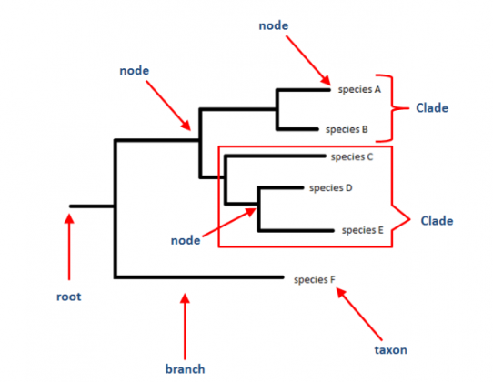

Diagram of phylogenetic tree terms from [10 differences between cladograms and phylogenetics trees](https://vivadifferences.com/difference-between-cladogram-and-phylogenetic-tree/)

## 1.1.0 Where does tree data come from?

As we saw last week, clustering analysis such as that from `hclust()` can create dendrogram data. We plotted this in a couple of ways by itself using `fviz_dend()` from the `factoextra` package and with `Heatmap()` from the `ComplexHeatmap` package. In the case of our first foray, we were looking at the “relationships” between samples by indicating how similar they were based on the characteristics in their various features.

Depending on the software used, trees can be represented in a number of formats, some of which are described below.

| Format | Description |
| --- | --- |
| Newick | The standard used to represent trees in a computer-readable format. Trees are encoded in a parentheses-closure format where each tip takes the form of “**taxa:branch-length**” |
|  | and pairs of tips are separated by a comma `,` and enclosed by parentheses `()`. Internal nodes branch lengths are defined outside the parentheses with “**():branch-length**” |
| NEXUS/phylip | Incorporates the Newick tree with separate related data that is partitioned into different blocks. Blocks are started with “**BEGIN <BLOCK NAME>;**” and closed with “**END;**” |
| NHX | New Hampshire eXtended format is also based on Newick format but instead of code blocks uses a tagging system for each node extending the format to “**taxa:branch-length[&&NHX:<tag information>]**” |

## 1.2.0 Using `read.tree()` from the `treeio` package

When opening tree files, depending on the format, you can use the `treeio` package and one of it’s many [parsing functions](https://yulab-smu.top/treedata-book/chapter1.html) but the simplest way to avoid figuring out how to open a tree file, is to just use the `read.tree()` function. This will determine the appropriate file type and parse through the many different tree formats before depositing the data into a `phylo` object.

Today we’ll be working with a dataset from the [Auspice COVID-19 North American dataset](http://auspice.finlaymagui.re/ncov/north-america/canada/ontario) maintained by [Finlay Maguire](https://finlaymagui.re/). **Unfortunately this dataset is no longer available but we have an older copy with a fair amount of metadata.**

Let’s begin by opening up the tree data and some related metadata before taking a look under the hood.

```r
# Import our Newick Tree
SC2_variants_time.phylo <- read.tree("data/nextstrain_ncov_north-america_canada_timetree.nwk")

# Import our metadata
SC2_metadata.df <- read_tsv("data/nextstrain_ncov_north-america_canada_metadata.tsv")
# What does the tree look like?
str(SC2_variants_time.phylo)
```

```
## List of 6
##  $ edge       : int [1:12776, 1:2] 6628 6628 6629 6630 6631 6630 6632 6632 6633 6629 ...
##  $ edge.length: num [1:12776] 0.0757 0.0848 0.0336 0.0501 0 ...
##  $ Nnode      : int 6150
##  $ node.label : chr [1:6150] "NODE_0008606" "NODE_0000001" "NODE_0000061" "USA/MA1/2020_travel_history" ...
##  $ tip.label  : chr [1:6627] "Wuhan/WH01/2019" "USA/MA1/2020" "Canada/ON_ON-VIDO-01-2/2020" "Canada/ON_VIDO-01/2020" ...
##  $ root.edge  : num 2020
##  - attr(*, "class")= chr "phylo"
##  - attr(*, "order")= chr "cladewise"
```

```r
SC2_variants_time.phylo
```

```
##
## Phylogenetic tree with 6627 tips and 6150 internal nodes.
##
## Tip labels:
##   Wuhan/WH01/2019, USA/MA1/2020, Canada/ON_ON-VIDO-01-2/2020, Canada/ON_VIDO-01/2020, USA/CA-CDC-5/2020, Taiwan/CGMH-CGU-02/2020, ...
## Node labels:
##   NODE_0008606, NODE_0000001, NODE_0000061, USA/MA1/2020_travel_history, NODE_0000062, Canada/ON_VIDO-01/2020_travel_history, ...
##
## Rooted; includes branch lengths.
```

### 1.2.1 The `phylo` object is a simple list

From the looks of our structure, after reading in our Newick file, we have a list with six elements. They are pretty clearly named with edge information (a matrix of paired numbers), edge lengths, a count of the number of nodes (ie *internal* points where branches bifurcate. While mostly just numbers, some of these `node.label` values appear to be based on travel history information. All of the 6,627 `tip.label` values correspond to 6,627 SARS-CoV-2 strain names found in the metadata file as well.

### 1.2.2 Convert the tree object to a tibble for adding external information

Suppose we want to combine some information from our metadata with our tree? We can then use this information to colour, shape, and bring more visual order to our tree. Working with the tree, however, can be a little hard given that we have lists of different lengths representing different portions of the tree.

In our case, we only have tree tip information that we want to add to and the easiest way to work would be if it was in a table format. The package `tidytree` provides a function `as_tibble` that will parse and convert the `phylo` format to a `tbl_tree` object, which is a kind of tidy data frame.

Let’s convert our variant phylo object to something we can work with.

```r
# Convert the phylo object using as_tibble
SC2_variants_time.tb <- as_tibble(SC2_variants_time.phylo)

# Check out the structure now
str(SC2_variants_time.tb)
```

```
## tbl_tree [12,777 x 4] (S3: tbl_tree/tbl_df/tbl/data.frame)
##  $ parent       : int [1:12777] 6628 6631 6632 6633 6636 6635 6638 6638 6639 6640 ...
##  $ node         : int [1:12777] 1 2 3 4 5 6 7 8 9 10 ...
##  $ branch.length: num [1:12777] 0.0757 0 0.0077 0 0 ...
##  $ label        : chr [1:12777] "Wuhan/WH01/2019" "USA/MA1/2020" "Canada/ON_ON-VIDO-01-2/2020" "Canada/ON_VIDO-01/2020" ...
```

```r
head(SC2_variants_time.tb)
```

```
## ! # Invaild edge matrix for <phylo>. A <tbl_df> is returned.
```

```
## # A tibble: 6 x 4
##   parent  node branch.length label
##    <int> <int>         <dbl> <chr>
## 1   6628     1       0.0757  Wuhan/WH01/2019
## 2   6631     2       0       USA/MA1/2020
## 3   6632     3       0.00770 Canada/ON_ON-VIDO-01-2/2020
## 4   6633     4       0       Canada/ON_VIDO-01/2020
## 5   6636     5       0       USA/CA-CDC-5/2020
## 6   6635     6       0.0442  Taiwan/CGMH-CGU-02/2020
```

## 1.3.0 Updating our tree with external information

As you can see our `SC2_variants_time.tb` object is a simple data frame now represented as a 4-column table with 12,777 rows. The edge data is encoded between the `parent` and `node` columns with `branch.length` to define the length of each edge. We also have all of the tip and node names stored under the `label` column. With the tree in this format, we can now treat the tree like a tibble and join additional information to the tree.

Rules to keep in mind:

1. Don’t lose any node information from your original tree structure. Losing “observations” is essentially losing edges of your tree!
2. Try to work with a complete dataset of information although sometimes it doesn’t make sense that you would have it all.
3. Convert your tibble back to a tree format when you’re done with `as.treedata()`

You may have information about the leaves or tips of your tree but by default there is no real internal node information when it comes to sample origins or lineage. When joining information to the tables, use the correct direction `*_join()` to avoid data loss. A `full_join()` is probably the safest.

Let’s take a quick look at our metadata and identify what we’re interested in.

```r
# Look at the metadata, which bits of information would be nice to add?
str(SC2_metadata.df, give.attr = FALSE)
```

```
## spc_tbl_ [6,627 x 24] (S3: spec_tbl_df/tbl_df/tbl/data.frame)
##  $ Strain                    : chr [1:6627] "Wuhan/WH01/2019" "USA/MA1/2020" "Canada/ON_ON-VIDO-01-2/2020" "Canada/ON_VIDO-01/2020" ...
##  $ GISAID clade              : chr [1:6627] "L" "L" "L" "L" ...
##  $ Nextstrain clade          : chr [1:6627] "19A" "19A" "19A" "19A" ...
##  $ Age                       : num [1:6627] 44 21 NA NA 54 NA 47 47 23 55 ...
##  $ Clade                     : chr [1:6627] "19A" "19A" "19A" "19A" ...
##  $ Country                   : chr [1:6627] "Asia" "USA" "Canada" "Canada" ...
##  $ Admin Division            : chr [1:6627] "Asia" "Massachusetts" "Ontario" "Ontario" ...
##  $ Admin Division of exposure: chr [1:6627] "Asia" "Asia" "Ontario" "Asia" ...
##  $ gisaid_epi_isl            : chr [1:6627] "EPI_ISL_406798" "EPI_ISL_409067" "EPI_ISL_425177" "EPI_ISL_413015" ...
##  $ Host                      : chr [1:6627] "Human" "Human" "Human" "Human" ...
##  $ Originating Lab           : chr [1:6627] "General Hospital of Central Theater Command of People's Liberation Army of China" "Massachusetts Department of Public Health" "Public Health Ontario" "Public Health Ontario Laboratory" ...
##  $ PANGO lineage             : chr [1:6627] "B" "B" "B" "B" ...
##  $ Submission Date           : chr [1:6627] "Older" "Older" "Older" "Older" ...
##  $ Region                    : chr [1:6627] "Asia" "North America" "North America" "North America" ...
##  $ Region of exposure        : chr [1:6627] "Asia" "Asia" "North America" "Asia" ...
##  $ Sex                       : chr [1:6627] "Male" "Male" "Male" "Male" ...
##  $ strain                    : chr [1:6627] "Wuhan/WH01/2019" "USA/MA1/2020" "Canada/ON_ON-VIDO-01-2/2020" "Canada/ON_VIDO-01/2020" ...
##  $ Emerging Nextstrain clade : chr [1:6627] "19A" "19A" "19A" "19A" ...
##  $ Submitting Lab            : chr [1:6627] "BGI & Institute of Microbiology, Chinese Academy of Sciences & Shandong First Medical University & Shandong Aca"| __truncated__ "Pathogen Discovery, Respiratory Viruses Branch, Division of Viral Diseases, Centers for Disease Control and Prevention" "Pu…
##  $ url                       : logi [1:6627] NA NA NA NA NA NA ...
##  $ Collection Data           : Date[1:6627], format: "2019-12-26" "2020-01-29" ...
##  $ Author                    : chr [1:6627] "Weijun Chen et al (https://dx.doi.org/10.1016/S0140-6736(20)30251-8)" "Clinton R. Paden et al (https://dx.doi.org/10.1101/2020.03.09.20032896)" "Amrit S. Boese et al" "Shari Tyson et al" ...
##  $ Country of exposure       : chr [1:6627] NA "Asia" NA "Asia" ...
##  $ Location                  : chr [1:6627] NA "Boston" NA NA ...
```

```r
# Check out some of the values for these variables

# Metadata information on the samples
unique(SC2_metadata.df$Country)
```

```
##  [1] "Asia"               "USA"                "Canada"
##  [4] "Europe"             "Guatemala"          "Panama"
##  [7] "Africa"             "Dominican Republic" "Costa Rica"
## [10] "South America"      "Oceania"            "Jamaica"
## [13] "Mexico"             "Barbados"           "Guadeloupe"
## [16] "Saint Martin"       "Bermuda"            "Sint Maarten"
## [19] "Saint Barthélemy"   "Belize"             "Saint Lucia"
## [22] "El Salvador"        "Cuba"
```

```r
unique(SC2_metadata.df$Age)
```

```
##   [1]  44  21  NA  54  47  23  55  62  49  50  43  25  26  33  38   9  73  64
##  [19]  57  58   0  28  70  71  20  93  36  37  40  56  89  45  34  53  94  95
##  [37]  86  84  60  90  27  30  59  41  46  52  51  32  24  35  29  61  79  66
##  [55]  78  11   2  65  75  31  48  74  68  67  63  77  42  22  12   5  17  80
##  [73]  16  39  82   8   7  88  76  69  19  87   3  14  18   1  81  15   6  10
##  [91]  85   4  98  91  72  99  13  92  83  96 104
```

```r
# Metadata information on the genomes
unique(SC2_metadata.df$'GISAID clade')
```

```
##  [1] "L"   "S"   "O"   "V"   "GR"  "G"   "GV"  "GH"  "GRY" NA
```

```r
unique(SC2_metadata.df$'Nextstrain clade')
```

```
##  [1] "19A"         "19B"         NA            "20A"         "20B"
##  [6] "20E (EU1)"   "20A.EU2"     "20C"         "20G"         "20H/501Y.V2"
## [11] "20D"         "20J/501Y.V3" "20F"         "20I/501Y.V1"
```

```r
unique(SC2_metadata.df$Clade)
```

```
##  [1] "19A"         "19B"         "20A"         "20E (EU1)"   "20C"
##  [6] "20G"         "20H/501Y.V2" "20B"         "20D"         "20J/501Y.V3"
## [11] "20F"         "20I/501Y.V1"
```

```r
unique(SC2_metadata.df$'PANGO lineage')
```

```
##   [1] "B"           "A"           "A.6"         "A.2"         "A.2.4"
##   [6] "A.2.5"       "A.5"         "A.1"         "A.21"        "A.18"
##  [11] "A.12"        "A.28"        "A.19"        "A.25"        "A.23"
##  [16] "A.23.1"      "B.12"        "B.56"        "B.4.7"       "B.31"
##  [21] "B.61"        "B.40"        "B.35"        "B.28"        "B.11"
##  [26] "B.55"        "B.27"        "B.3"         "B.4"         "B.4.8"
##  [31] "B.4.2"       "B.53"        "B.6"         "B.1"         "B.6.6"
##  [36] "B.6.1"       "B.6.2"       "B.6.8"       "B.1.256"     "B.1.1"
##  [41] "B.1.1.420"   "B.1.240"     "B.1.205"     "B.1.128"     "B.1.221"
##  [46] "B.1.223"     "B.1.214.2"   "B.1.214"     "B.1.146"     "B.1.147"
##  [51] "B.1.104"     "B.1.391"     "B.1.380"     "B.1.203"     "B.1.540"
##  [56] "B.1.416"     "B.1.600"     "B.1.160"     "B.1.195"     "B.1.609"
##  [61] "B.1.561"     "B.1.232"     "B.1.558"     "B.1.239"     "B.1.237"
##  [66] "B.1.597"     "B.1.480"     "B.1.397"     "B.1.408"     "B.1.243"
##  [71] "B.1.240.2"   "B.1.240.1"   "B.1.524"     "B.1.179"     "B.1.1.298"
```

[output cut: 75 more lines]

### 1.3.1 Pick the tip attributes that are most interesting or relevant

For our purposes it looks like we will want to explore our data with:

- GISAID clade: A **g**lobal **i**nitiative on **s**haring **a**vian **i**nfluenza **d**ata scientific consortium of clade naming.
- Nextstrain clade: Computationally labeled clade information based on the [Nextstrain](https://nextstrain.org/) criteria and analysis of new and continuing strains from COVID genomic data.
- Emerging Nextstrain clade.
- PANGO lineage: a dynamic nomenclature of [SARS-CoV-2 lineages](https://en.wikipedia.org/wiki/Phylogenetic_Assignment_of_Named_Global_Outbreak_Lineages).
- Country: The country where the sample was collected.
- Admin Division: geographic location of the particular strain/case.
- Age: the age of the patients from which the sample was collected (if included)
- Collection Data: the date the data was published or collected.
- Strain: the name of the strain which we’ll need for merging with our tree structure.

Let’s pull that information down and add it to our `tbl_tree` before converting it to a `treedata` object.

```r
# Add phylogenetic information to our tree
SC2_variants_time.tree <-

  # Pass along the metadata
  SC2_metadata.df %>%

  # Select just a handful of attributes to go to the tree
  select(Strain, 'GISAID clade', 'Emerging Nextstrain clade',
         'PANGO lineage', Country, 'Admin Division', 'Collection Data', Age) %>%

  rename(strain = Strain,
         GISAID = 'GISAID clade',
         emerging_nextstrain = 'Emerging Nextstrain clade',
         PANGO = 'PANGO lineage',
         strain_country = Country,
         strain_division = 'Admin Division',
         strain_date = 'Collection Data') %>%

  # full_join to our tree to ensure no data is lost although you could also carefully use a left_join
  left_join(x=SC2_variants_time.tb, y=., by=c("label" = "strain")) %>%

  # Convert to a tidytree format
  as.treedata()

# Look at the resulting structure
str(SC2_variants_time.tree)
```

```
## Formal class 'treedata' [package "tidytree"] with 11 slots
##   ..@ file       : chr(0)
##   ..@ treetext   : chr(0)
##   ..@ phylo      :List of 5
##   .. ..$ edge       : int [1:12776, 1:2] 6628 6631 6632 6633 6636 6635 6638 6638 6639 6640 ...
##   .. .. ..- attr(*, "dimnames")=List of 2
##   .. .. .. ..$ : NULL
##   .. .. .. ..$ : chr [1:2] "parent" "node"
##   .. ..$ edge.length: num [1:12776] 0.0757 0 0.0077 0 0 ...
##   .. ..$ tip.label  : chr [1:6627] "Wuhan/WH01/2019" "USA/MA1/2020" "Canada/ON_ON-VIDO-01-2/2020" "Canada/ON_VIDO-01/2020" ...
##   .. ..$ node.label : chr [1:6150] "NODE_0008606" "NODE_0000001" "NODE_0000061" "USA/MA1/2020_travel_history" ...
##   .. ..$ Nnode      : int 6150
##   .. ..- attr(*, "class")= chr "phylo"
##   ..@ data       : tibble [12,777 x 8] (S3: tbl_df/tbl/data.frame)
##   .. ..$ node               : int [1:12777] 1 2 3 4 5 6 7 8 9 10 ...
##   .. ..$ GISAID             : chr [1:12777] "L" "L" "L" "L" ...
##   .. ..$ emerging_nextstrain: chr [1:12777] "19A" "19A" "19A" "19A" ...
##   .. ..$ PANGO              : chr [1:12777] "B" "B" "B" "B" ...
##   .. ..$ strain_country     : chr [1:12777] "Asia" "USA" "Canada" "Canada" ...
##   .. ..$ strain_division    : chr [1:12777] "Asia" "Massachusetts" "Ontario" "Ontario" ...
##   .. ..$ strain_date        : Date[1:12777], format: "2019-12-26" "2020-01-29" ...
##   .. ..$ Age                : num [1:12777] 44 21 NA NA 54 NA 47 47 23 55 ...
##   ..@ extraInfo  : tibble [0 x 0] (S3: tbl_df/tbl/data.frame)
##  Named list()
##   ..@ tip_seq    : NULL
##   ..@ anc_seq    : NULL
##   ..@ seq_type   : chr(0)
##   ..@ tipseq_file: chr(0)
##   ..@ ancseq_file: chr(0)
##   ..@ info       : list()
```

### 1.3.1.1 How to access S4 object types

Take a quick look at the structure of this treedata object. What do we see? The `treedata` class has converted our tibble back into an **S4** object with 11 slots. Each slot, is essentially a placeholder for another object. We can access these slots using the `@` operator and we can further access sub elements with the `$` operator.

For instance, we can see there is a `phylo` slot which looks suspiciously like our original `SC2_variants_time.phylo` object. The rest of our data frame information, which we just added to the `tbl_tree` before converting it is stored in the `data` slot. There are additional slots where we can add sequencing information for comparison in different types of phylogenetic tree visualizations.

```r
# Grab our phylo object
SC2_variants_time.tree@phylo
```

```
##
## Phylogenetic tree with 6627 tips and 6150 internal nodes.
##
## Tip labels:
##   Wuhan/WH01/2019, USA/MA1/2020, Canada/ON_ON-VIDO-01-2/2020, Canada/ON_VIDO-01/2020, USA/CA-CDC-5/2020, Taiwan/CGMH-CGU-02/2020, ...
## Node labels:
##   NODE_0008606, NODE_0000001, NODE_0000061, USA/MA1/2020_travel_history, NODE_0000062, Canada/ON_VIDO-01/2020_travel_history, ...
##
## Unrooted; includes branch lengths.
```

```r
# Take a peek at our associated node data
head(SC2_variants_time.tree@data)
```

```
## # A tibble: 6 x 8
##    node GISAID emerging_nextstrain PANGO strain_country strain_division
##   <int> <chr>  <chr>               <chr> <chr>          <chr>
## 1     1 L      19A                 B     Asia           Asia
## 2     2 L      19A                 B     USA            Massachusetts
## 3     3 L      19A                 B     Canada         Ontario
## 4     4 L      19A                 B     Canada         Ontario
## 5     5 L      19A                 B     USA            California
## 6     6 S      19A                 B     Asia           Asia
## # i 2 more variables: strain_date <date>, Age <dbl>
```

## 1.4.0 Plot your tree with `ggtree()` from the `ggtree` package

Now that we’ve put some extra data into our tree, we are ready to plot it with the help of the `ggtree()` function from the `ggtree` package. If you haven’t noticed yet, `treeio`, `tidytree` and `ggtree` form a suite of packages that we can use to import, alter, and visualize our trees.

Parameters for `ggtree()` include:

- `tr`: the phylo tree object
- `layout`: the shape of the tree including: rectangular, dendrogram, slanted, ellipse, fan, circular, inward_circular, and radial.
- `mrsd`: most recent sampling date used for setting a time-based scale
- `as.Date`: logical to specify if date will be in calendar vs decimal-date format
- `branch.length`: variable for scaling branch length
- `root.position`: the position of our root node (default = 0)

You’ll notice that `ggtree()` appears to act very much like the `ggplot()` command. We’ll be able to add layers to the base visualization much like we do with other ggplot objects. We’ll also use `theme_tree2()` which will automatically add an x-axis scale to our tree.

We’ll start simple by just visualizing all 6,627 tips of our tree.

```r
# Show the entire tree

SC2_variants_time.tree %>%

# 1. Data
ggtree(tr = .) +
  # 2. Aesthetics
  aes(color = emerging_nextstrain) +

  # Themes
  theme_tree2() +
  theme(text = element_text(size = 20),
        legend.position = "bottom") + # Move our legend to the bottom

  # Provide some labels
  labs(x="Time",
       title = "Canada and US sequenced strain phylogeny") +

  # Make our guide lines a little thicker
  guides(colour = guide_legend(title = "Nextstrain\nclade",
                                        override.aes = list(size=2)))
```

[output not shown]

## 1.5.0 Filter your tree using `drop.tip()`

As it stands, there’s just way too much data here to look at and work with. We can trim that data using the `drop.tip()` function without worrying about how the tree is parsed. Internally, all that pruning will take place within the function. To do this, we’ll generate a list of tips we want to *remove* first.

```r
# You can make a list of tips to drop when you're making your ggtree

# Generate a table of tree information to drop
to_drop <-

  SC2_metadata.df %>%

  # Filter for strains that are not from Canada and are from before 2020-11-01
  filter(!(Country == "Canada" &
           `Collection Data` >= as.Date("2020-11-01")
          )) %>%

  # Just keep the strain information
  pull(Strain)

# Take a look at what we got back
str(to_drop)
```

```
##  chr [1:6199] "Wuhan/WH01/2019" "USA/MA1/2020" ...
```

```r
# At the same time make a dataset to keep. You'll use this to update the information in the tree later
to_keep <- SC2_metadata.df %>% filter(!Strain %in% to_drop)

# Which tips are we keeping?
str(to_keep, give.attr = FALSE)
```

```
## spc_tbl_ [428 x 24] (S3: spec_tbl_df/tbl_df/tbl/data.frame)
##  $ Strain                    : chr [1:428] "Canada/NS-NML-16223/2021" "Canada/NB-NML-3294/2021" "Canada/NS-NML-16211/2021" "Canada/NB-NML-5584/2021" ...
##  $ GISAID clade              : chr [1:428] "S" "S" "S" "S" ...
##  $ Nextstrain clade          : chr [1:428] "19B" "19B" "19B" "19B" ...
##  $ Age                       : num [1:428] 23 25 35 29 61 79 NA NA NA NA ...
##  $ Clade                     : chr [1:428] "19B" "19B" "19B" "19B" ...
##  $ Country                   : chr [1:428] "Canada" "Canada" "Canada" "Canada" ...
##  $ Admin Division            : chr [1:428] "Nova Scotia" "New Brunswick" "Nova Scotia" "New Brunswick" ...
##  $ Admin Division of exposure: chr [1:428] "Nova Scotia" "New Brunswick" "Nova Scotia" "New Brunswick" ...
##  $ gisaid_epi_isl            : chr [1:428] "EPI_ISL_1055741" "EPI_ISL_961659" "EPI_ISL_1055730" "EPI_ISL_961643" ...
##  $ Host                      : chr [1:428] "Human" "Human" "Human" "Human" ...
##  $ Originating Lab           : chr [1:428] "QEII Health Sciences Centre" "Hôpital Georges L. Dumont" "QEII Health Sciences Centre" "Hôpital Georges L. Dumont" ...
##  $ PANGO lineage             : chr [1:428] "A.2.5" "A.23.1" "A.23.1" "A.23.1" ...
##  $ Submission Date           : chr [1:428] "Older" "Older" "Older" "Older" ...
##  $ Region                    : chr [1:428] "North America" "North America" "North America" "North America" ...
##  $ Region of exposure        : chr [1:428] "North America" "North America" "North America" "North America" ...
##  $ Sex                       : chr [1:428] "Male" "Female" "Female" "Male" ...
##  $ strain                    : chr [1:428] "Canada/NS-NML-16223/2021" "Canada/NB-NML-3294/2021" "Canada/NS-NML-16211/2021" "Canada/NB-NML-5584/2021" ...
##  $ Emerging Nextstrain clade : chr [1:428] "19B" "19B" "19B" "19B" ...
##  $ Submitting Lab            : chr [1:428] "National Microbiology Laboratory (NML)" "National Microbiology Laboratory (NML)" "National Microbiology Laboratory (NML)" "National Microbiology Laboratory (NML)" ...
##  $ url                       : logi [1:428] NA NA NA NA NA NA ...
##  $ Collection Data           : Date[1:428], format: "2021-01-16" "2021-01-02" ...
##  $ Author                    : chr [1:428] "Anna Majer et al" "Anna Majer et al" "Anna Majer et al" "Anna Majer et al" ...
##  $ Country of exposure       : chr [1:428] NA NA NA NA ...
##  $ Location                  : chr [1:428] NA NA NA NA ...
```

## 1.6.0 Update our pruned tree and add some extra `geom_*` layers

The `ggtree` package brings a number of `ggplot2`-compatible geoms to our finger-*tips*. We’ll spruce up our tree with some tip labels to begin with. We’ll accomplish this with the `geom_tiplab()` layer.

| Component type | Layer type | Command | Description |
| --- | --- | --- | --- |
| Tree | Geom | geom_tree | tree structure layer, with multiple layout supported |
| Tree | Geom | geom_treescale | tree branch scale legend |
| Node | Geom | geom_nodepoint | annotate internal nodes with symbolic points |
| Node | Annotation | geom_range | bar layer to present uncertainty of evolutionary inference |
| Node | Annotation | geom_rootpoint | annotate root node with symbolic point |
| Branch | Annotation | geom_label2 | modified version of geom_label, with subsetting supported for labelling branches |
| Branch | Annotation | geom_segment2 | modified version of geom_segment, with subsetting supported |
| Taxa | Geom | geom_point2 | modified version of geom_point, with subsetting supported |
| Taxa | Geom | geom_tippoint | annotate external nodes with symbolic points |
| Taxa | Annotation | geom_taxalink | associate two related taxa by linking them with a curve |
| Taxa | Annotation | geom_text2 | modified version of geom_text, with subsetting supported |
| Taxa | Annotation | geom_tiplab | layer of tip labels |
| Taxa | Annotation | geom_tiplab2 | layer of tip labels for circular layout |
| Clade | Annotation | geom_balance | highlights the two direct descendant clades of an internal node |
| Clade | Annotation | geom_cladelabel | annotate a clade with bar and text label |
| Clade | Annotation | geom_hilight | highlight a clade with rectangle |
| Clade | Annotation | geom_strip | annotate associated taxa with bar and (optional) text label |

```r
# Show our pruned tree

SC2_variants_time.tree %>%
  # drop tips based on our list
  drop.tip(., to_drop) %>%

  # 1. Data
  ggtree(tr = .) + # Need the most recent sampling date
    # 2. Aesthetics
    aes(color = emerging_nextstrain) +

    # Themes
    theme_tree2() +
    theme(text = element_text(size = 20),
          legend.position = "bottom") + # Move our legend to the bottom

    # Provide some labels
    labs(x="Time",
         title = "Subset of Canadian sequenced strains") +

    # Make our guide lines a little thicker
    guides(colour = guide_legend(title = "Nextstrain\nclade",
                                          override.aes = list(size=2))) +

    # 4. Geoms
    ### 1.6.0 Add tips labels to our tree tips
    geom_tiplab()
```

[output not shown]

### 1.6.1 Replace labels with points using different geoms

- `geom_point()`
- `geom_nodepoint()`
- `geom_tippoint()`

If we use `geom_point()` we can colour/annotate all of the nodes and tips but we already know that there isn’t any phylogenetic information associated with our internal nodes. Likewise, `geom_nodepoint()` will allow us to colour the nodes but there isn’t any grouping information associated with that.

Therefore we’ll use `geom_tippoint()` to colour our tips based on their Nextstrain clade information and we can alter the tip shape to match the province where the strain was sequenced.

```r
# Show entire tree

SC2_variants_time.tree %>%
  drop.tip(., to_drop) %>%

  # 1. Data
  ggtree(tr = .) + # Need the most recent sampling date
    # 2. Aesthetics
    aes(color = emerging_nextstrain) +

    # Themes
    theme_tree2() +
    theme(text = element_text(size = 20),
          legend.position = "bottom", # Move our legend to the bottom
          legend.box = "vertical") +  # Stack legends vertically

    # Provide some labels
    labs(x="Time",
         title = "Subset of Canadian sequenced strains") +

    # Make our guide lines a little thicker
    guides(colour = guide_legend(title = "Nextstrain\nclade",
                                          override.aes = list(size=2)),
           shape = guide_legend(title = "Strain\nlocation")
          ) +

    # 3. Scaling
    scale_shape_manual(values = c(15:20, 11)) +

    # 4. Geoms
    # Add tips labels to our tree tips
    ### 1.6.1 Change our tip shape by strain_division
    geom_tippoint(aes(shape=strain_division), alpha = 0.7, size =3)  # Add tips only
```

[output not shown]

### 1.6.2 Fix your x-axis with the `mrsd` parameter

```r
# Show entire tree

SC2_variants_time.tree %>%
  drop.tip(., to_drop) %>%

  # 1. Data
  ggtree(tr = .,
       mrsd = "2021-02-17",    ### 1.6.2 Set the most recent sampling date
       as.Date = TRUE) +       ### 1.6.2 Make sure it's set as a data
    # 2. Aesthetics
    aes(color = emerging_nextstrain) +

    # Themes
    theme_tree2() +
    theme(text = element_text(size = 20),
          legend.position = "bottom", # Move our legend to the bottom
          legend.box = "vertical") +  # Stack legends vertically

    # Provide some labels
    labs(x="Time",
         title = "Subset of Canadian sequenced strains") +

    # Make our guide lines a little thicker
    guides(colour = guide_legend(title = "Nextstrain\nclade",
                                          override.aes = list(size=2)),
           shape = guide_legend(title = "Strain\nlocation")
          ) +

    # 3. Scaling
    scale_shape_manual(values = c(15:20, 11)) +

    # 4. Geoms
    # Add tips labels to our tree tips
    # Change our tip shape by strain_division
    geom_tippoint(aes(shape = strain_division), alpha = 0.7, size = 3)  # Add tips only
```

[output not shown]

## 1.7.0 Thin out the tree some more with `viewClade()` and other information functions

| function | Description |
| --- | --- |
| child() | Find the children of an internal node. |
| parent() | Find the parent node of a tip or other node. |
| offspring() | Find all of the offspring of a node. |
| ancestor() | Find all of the ancestors of a tip or node |
| sibling() | Find the nearest sibling of a tip (or node) |
| MRCA() | Find the most recent common ancestor between two or more nodes |

Let’s filter our taxa list a little more searching for variants of the clade 501Y.V1 and 501Y.V2. Then we’ll find the MRCA between those tips.

```r
# You can make a list of tips to drop when you're making your ggtree

# Generate a table of tree information to drop
to_view <-

  SC2_metadata.df %>%

    # Filter our tip information
    filter(`Emerging Nextstrain clade` %in% c("20I/501Y.V1", "20H/501Y.V2") &
           Country == "Canada" &
           `Collection Data` >= as.Date("2021-02-16")
          ) %>%

    # Just keep the strain names
    pull(Strain)

# What's the list look like?
to_view
```

```
##  [1] "Canada/NL-NML-17170/2021" "Canada/NL-NML-17182/2021"
##  [3] "Canada/NL-NML-17173/2021" "Canada/NL-NML-17193/2021"
##  [5] "Canada/NL-NML-17157/2021" "Canada/NL-NML-17185/2021"
##  [7] "Canada/NL-NML-17189/2021" "Canada/NL-NML-17196/2021"
##  [9] "Canada/NL-NML-17184/2021" "Canada/NL-NML-17166/2021"
## [11] "Canada/NL-NML-17191/2021" "Canada/NL-NML-17172/2021"
## [13] "Canada/NL-NML-17187/2021" "Canada/NL-NML-17168/2021"
## [15] "Canada/NL-NML-17194/2021" "Canada/NL-NML-17158/2021"
## [17] "Canada/NL-NML-17183/2021" "Canada/NL-NML-17165/2021"
```

```r
# Calculate the MRCA from a subset of our tips

to_view_MRCA <-
  # Pass along our tree information
  SC2_variants_time.tree %>%

  # Get rid of the tips we would before (to match the tree we'll plot)
  drop.tip(., to_drop) %>%

  # Determine the MRCA between the first 4 tips in the list
  MRCA(., to_view[1:4])
```

```
## ! # Invaild edge matrix for <phylo>. A <tbl_df> is returned.
```

```r
# What kind of value does MRCA() return?
to_view_MRCA
```

```
## [1] 727
```

```r
# How many offspring does it have?

# Pass along our tree information
SC2_variants_time.tree %>%

  # Drop our original set of tips
  drop.tip(., to_drop) %>%
  # make a tibble so we can see all the relevant information
  as_tibble() %>%
  # Find the offspring of a specific node
  offspring(., to_view_MRCA) %>%
  # Convert to a tree
  as.treedata() %>%
  str()
```

```
## ! # Invaild edge matrix for <phylo>. A <tbl_df> is returned.
```

```
## Formal class 'treedata' [package "tidytree"] with 11 slots
##   ..@ file       : chr(0)
##   ..@ treetext   : chr(0)
##   ..@ phylo      :List of 5
##   .. ..$ edge       : int [1:71, 1:2] 728 730 731 732 732 734 735 735 736 737 ...
##   .. .. ..- attr(*, "dimnames")=List of 2
##   .. .. .. ..$ : NULL
##   .. .. .. ..$ : chr [1:2] "parent" "node"
##   .. ..$ edge.length: num [1:71] 0.1136 0.067 0.0521 0.0306 0.0333 ...
##   .. ..$ tip.label  : chr [1:39] "Canada/NL-NML-16819/2021" "Canada/NL-NML-16824/2021" "Canada/NL-NML-17178/2021" "Canada/NL-NML-16829/2021" ...
##   .. ..$ node.label : chr [1:32] "NODE_0006538" "NODE_0006539" "NODE_0006540" "NODE_0006541" ...
##   .. ..$ Nnode      : int 32
##   .. ..- attr(*, "class")= chr "phylo"
##   ..@ data       : tibble [71 x 8] (S3: tbl_df/tbl/data.frame)
##   .. ..$ node               : int [1:71] 323 324 325 326 327 328 329 330 331 332 ...
##   .. ..$ GISAID             : chr [1:71] "GRY" "GRY" "GRY" "GRY" ...
##   .. ..$ emerging_nextstrain: chr [1:71] "20I/501Y.V1" "20I/501Y.V1" "20I/501Y.V1" "20I/501Y.V1" ...
##   .. ..$ PANGO              : chr [1:71] "B.1.1.7" "B.1.1.7" "B.1.1.7" "B.1.1.7" ...
##   .. ..$ strain_country     : chr [1:71] "Canada" "Canada" "Canada" "Canada" ...
##   .. ..$ strain_division    : chr [1:71] "Newfoundland and Labrador" "Newfoundland and Labrador" "Newfoundland and Labrador" "Newfoundland and Labrador" ...
##   .. ..$ strain_date        : Date[1:71], format: "2021-02-10" "2021-02-12" ...
##   .. ..$ Age                : num [1:71] 47 16 26 62 60 45 19 45 35 31 ...
##   ..@ extraInfo  : tibble [0 x 0] (S3: tbl_df/tbl/data.frame)
##  Named list()
##   ..@ tip_seq    : NULL
##   ..@ anc_seq    : NULL
##   ..@ seq_type   : chr(0)
##   ..@ tipseq_file: chr(0)
##   ..@ ancseq_file: chr(0)
##   ..@ info       : list()
```

### 1.7.1 Pass a `ggplot2` object to `viewClade()`

We see that our chosen MRCA node (727) has 39 children based on the number of tip labels in our `treedata` object. We can also now use this MRCA to determine the specific clade we can see on the tree but this will still be quite large. To view this particular clade, we build our plot as before, and then zoom into it afterwards with the `viewClade()` function.

Unfortunately, we’ll have to ditch our date scale and revert to a decimal-date. If you’re not using a calendar-based date, it’s not a problem at all. If we look carefully at the data, we’ll see that the internal nodes have an NA-value. If you were *industrious enough*, you could use the branch lengths to traverse the tree and calculate dates for all the internal nodes as well. This would likely solve the issue.

Let’s drop the tip names back in there too.

```r
# Show a small clade of the tree

tree.plot <-

SC2_variants_time.tree %>%
  # From our tree, drop the Non-Canadian tips
  drop.tip(., to_drop) %>%

  # 1. Data
  ggtree(tr = ., mrsd = "2021-02-16") + # Need the most recent sampling date
    # 2. Aesthetics
    aes(color = emerging_nextstrain) +

    # Themes
    theme_tree2() +
    theme(text = element_text(size = 30),
          legend.position = "bottom", # Move our legend to the bottom
          legend.box = "vertical") +  # Stack legends vertically

    # Provide some labels
    labs(x="Time",
         title = "Subset of Canadian sequenced strains") +

    # Make our guide lines a little thicker
    guides(colour = guide_legend(title = "Nextstrain\nclade",
                                          override.aes = list(size=2)),
           shape = guide_legend(title = "Strain\nlocation")
          ) +

    # 3. Scaling
    scale_shape_manual(values = c(15:20, 11)) +

    # 4. Geoms
    geom_tiplab(size = 7, align=TRUE) + # Add labels in and right-align them

    # Add tips labels to our tree tips
    # Change our tip shape by strain_division
    geom_tippoint(aes(shape = strain_division), size = 3)  # Add tips only
```

[output not shown]

```r
### 1.7.1 View the clade we made using the same MRCA call we already used.
viewClade(tree.plot, MRCA(tree.plot, to_view[1:5]))
```

[output not shown]

## 1.8.0 Make a new subplot with information from across all clades

So we’ve looked at a few ways to subset and plot our phylogenetic tree. We’ll do a quick aside to create a more curated list of tips with representation from across multiple clades. We’ll use this as the base tree for our next few graphs so that we can really see the power of using additional information from our `treedata` object.

```r
# Here's our representative list of tips from multiple clades

curated_tips <-
c('Wuhan/WH01/2019',
'Canada/ON_ON-VIDO-01-2/2020',
'Canada/ON_VIDO-01/2020',
'Canada/BC_37_0-2/2020',
'Canada/BC_69243/2020',
'Canada/QC-CHUM-2008003956A/2020',
'Canada/NL-NML-1387/2020',
'Canada/MB-NML-808/2020',
'Canada/NB-NML-16967/2021',
'Canada/BC_6129127/2020',
'Canada/AB-97776/2020',
'Canada/AB-12948/2020',
'Canada/BC-BCCDC-3564/2020',
'Canada/ON-S67/2020',
'Canada/AB-65233/2020',
'Canada/MB-NML-1057/2020',
'Canada/ON-UHTC-0366/2020',
'Canada/NS-NML-16218/2021',
'Canada/NB-NML-16966/2021',
'Canada/NS_13/2020',
'Canada/Qc-CHUM-2019203856A/2020',
'Canada/NB-NML-3272/2020',
'Canada/ON-UHTC-0267/2020',
'Canada/MB-NML-1037/2020',
'Canada/NS-NML-5213/2020',
'Canada/NS-NML-5141/2021',
'Canada/NS-NML-5140/2021',
'Canada/NS-NML-16208/2021',
'Canada/BC-BCCDC-7012/2020',
'Canada/ON-LTRI-1372/2020',
'Canada/BC-BCCDC-9736/2021',
'Canada/ON-S2125/2021',
'Canada/NS-NML-5181/2020',
'Canada/ON-PPS-21012021_0269/2021',
'Canada/QC-L00314539/2020',
'Canada/NS-NML-16238/2021',
'Canada/NL-NML-16822/2021',
'Canada/QC-L00324589001/2021',
'Canada/NL-NML-17194/2021')
```

```r
# Make a new list of tips to drop
curated_drop_list <-
  SC2_metadata.df %>%

  # filter the opposite of our tip labels
  filter(!(Strain %in% curated_tips)) %>%
  # Only keep the strain information for what we want to drop
  pull(Strain)
```

```r
# Drop tips from our tree and save it as curated_tree_info.df
curated_tree_info.df <-

  # Pass along our original tree
  SC2_variants_time.tree %>%

  # Drop the tips we created
  drop.tip(., curated_drop_list) %>%

  # Convert to a tibble
  as_tibble() %>%

  # Rename our column information
  rename(Clade = emerging_nextstrain, Province = strain_division) %>%

  mutate(Age = replace_na(Age, replace = 0)) %>%

  # Convert this to a data frame
  as.data.frame()

# Set the rownames from the label information
rownames(curated_tree_info.df) <- curated_tree_info.df$label

# Let's view the tree
str(curated_tree_info.df)
```

```
## 'data.frame':    72 obs. of  11 variables:
##  $ parent        : int  40 42 42 44 44 45 45 46 46 48 ...
##  $ node          : int  1 2 3 4 5 6 7 8 9 10 ...
##  $ branch.length : num  0.0757 0.0077 0.0077 0.1439 0.0729 ...
##  $ label         : chr  "Wuhan/WH01/2019" "Canada/ON_ON-VIDO-01-2/2020" "Canada/ON_VIDO-01/2020" "Canada/MB-NML-808/2020" ...
##  $ GISAID        : chr  "L" "L" "L" "S" ...
##  $ Clade         : chr  "19A" "19A" "19A" "19B" ...
##  $ PANGO         : chr  "B" "B" "B" "A.1" ...
##  $ strain_country: chr  "Asia" "Canada" "Canada" "Canada" ...
##  $ Province      : chr  "Asia" "Ontario" "Ontario" "Manitoba" ...
##  $ strain_date   : Date, format: "2019-12-26" "2020-01-23" ...
##  $ Age           : num  44 0 0 0 27 59 0 43 35 53 ...
```

## 1.9.0 Convert your tree style with the `layout` parameter

So we’ve only been working with a rectangular tree (horizontal layout) thus far but as we mentioned at the beginning there are actually a number of different layouts we can use. Our goal now is to make a sort of sunburst plot using a circular layout that we’ll add visual categorical information to in a ring pattern.

First, we’ll start with the circular version. We’ll colour our tips by the province where the case or data was generated and label them by the Nextstrain clade information.

```r
# Show our curated tree in a circular format

tree.plot <-

  SC2_variants_time.tree %>%
  drop.tip(., curated_drop_list)  %>%

  # 1. Data
  ggtree(., layout = "circular", ### 1.9.0 Set the layout to circular
         mrsd = "2021-02-17") + # Need the most recent sampling date
    # 2. Aesthetics

    # Themes
    theme(text = element_text(size = 20),
          legend.position = "bottom") +
    labs(title = "Canada and US sequenced strain phylogeny",
         colour = "Province") +

    scale_colour_viridis_d(option = "plasma") + # This seems to literally kill the kernel!

    # 4. Geoms
    geom_tippoint(aes(colour = strain_division), size = 5) +

    ### 1.9.0 set the tip labels
    geom_tiplab(aes(label = emerging_nextstrain), size = 8)
```

[output not shown]

```r
# View our tree
tree.plot
```

[output not shown]

## 1.10.0 Use `gheatmap()` layer to add information to your plot

Now that we have our basic circular tree, we can use the information from `curated_tree_info.df` to visualize additional data on our tree. In order to use the `gheatmap` layer properly, we must pass it our original tree plot, along with a new dataframe (or vector) that holds the information we want to add. It should use the rownames from the data frame to help match up to the tips in our tree.

We’ll drop the tip labels from our tree in favour of the heatmap we’ll add. By adding layers of hierarchical data, this creates what is known as a **Sunburst** plot.

The gheatmap() layer takes some of the following parameters:

- `p`: the tree plot we want to modify.
- `data`: the data used to modify the tree plot `p`.
- `offset`: determines the offset of the heatmap relative to the tree.
- `width`: determines the total width of the heatmaps compared to the tree
- `colnames_angle`: determines the angle of the text for the heatmap.
- `font.size`: sets the font size for the heatmap portion of the tree.

```r
# Show our curated tree in a circular format

tree.plot <-

  SC2_variants_time.tree %>%
  drop.tip(., curated_drop_list)  %>%

  # 1. Data
  ggtree(., layout = "circular", mrsd = "2021-02-17") + # Need the most recent sampling date
    # 2. Aesthetics

    # Themes
    theme(text = element_text(size = 20),
          legend.position = "bottom") +
    labs(title = "Canada and US sequenced strain phylogeny",
         colour = "Province") +

    scale_colour_viridis_d(option = "plasma") +

    # 4. Geoms
    geom_tippoint(aes(colour = strain_division), size = 5) # Add tips only
```

[output not shown]

```r
### 1.10.0 Add a circular heatmap with gheatmap()
tree.plot <- gheatmap(tree.plot, curated_tree_info.df %>% select(parent, node, branch.length),
                      offset = 0.1, width = 0.1,
                      colnames_angle = 90, font.size = 6, hjust = 1) +
  scale_fill_continuous(name = "Tree coding")
```

[output not shown]

```r
tree.plot
```

[output not shown]

### 1.10.1 `ggnewscale` package allows multiple color/fill scales on your Sunburst plot

Instead, we’d like to separate the colour/fill scales by repeatedly adding to our plot, layer by layer. As you might recall, however, we also run into the problem of `scale_colour_*` and `scale_fill_*` layers overwriting any *previous* layers.

To circumvent this reality, we’ll use the `ggnewscale` package to generate new colour and fill scales with `new_scale_fill()` and `new_scale_colour()`. It can make the process slightly more encumbering but it will work out.

We’ll add back in our original tip labels as well for this graph.

```r
# Show our curated tree in a circular format

# We'll need some extra colour sets to accomplish this plot
combo.colours = c(brewer.pal(12, "Paired"), brewer.pal(8, "Set1"), brewer.pal(12, "Set3"))


# Save our first plot with just the tree
tree.plot <-

  SC2_variants_time.tree %>%
  drop.tip(., curated_drop_list)  %>%

  # 1. Data
  ggtree(., layout = "circular", mrsd = "2021-02-17") + # Need the most recent sampling date
    # 2. Aesthetics

    # Themes
    theme(text = element_text(size = 30),
          legend.position = "bottom") +
    labs(title = "Canada and US sequenced strain phylogeny") +

    # We'll want to ensure our colour guide ends up in the correct order
    scale_colour_discrete(guide = guide_legend(title="Province", order=1)) +

    # 4. Geoms
    geom_tippoint(aes(colour = strain_division), size = 5) + # Add tips only
    geom_tiplab(size = 10, align=TRUE, offset = 0.6) # Add in our labels
```

[output not shown]

```r
# Generate our first heatmap layer
tree.plot <- gheatmap(tree.plot, curated_tree_info.df %>% select(parent, node, branch.length),
                      offset = 0.1, width = 0.1,
                      colnames_angle = 90, font.size = 6) +
  # Set the name of our legend
  scale_fill_continuous(name = "Tree coding",
                        guide = guide_legend(order = 2))
```

[output not shown]

```r
### 1.10.1 use this code to create a new colour scale
tree.plot <- tree.plot + new_scale_fill()
```

[output not shown]

```r
# Generate a categorical heatmap layer for the Clade variable
tree.plot <- gheatmap(tree.plot, curated_tree_info.df %>% select(Clade),
                      offset = 0.2, width = 0.1,
                      colnames_angle = 90, font.size = 12) +

  # Set the name and order of our Clade legend
  scale_fill_discrete(name = "Nextstrain\nClade",
                      guide = guide_legend(order=3))
```

[output not shown]

```r
### 1.10.1 use this code to create a new colour scale
tree.plot <- tree.plot + new_scale_fill()
```

[output not shown]

```r
# Generate a categorical heatmap layer for the PANGO variable
tree.plot <- gheatmap(tree.plot, curated_tree_info.df %>% select(PANGO),
                      offset = 0.35, width = 0.1,
                      colnames_angle = 90, font.size = 12) +

  # Set the name and order of our PANGO legend
  scale_fill_manual(values = combo.colours, name = "PANGO\nlineage",
                    guide=guide_legend(order=4))
```

[output not shown]

```r
# You may need to re-render to see it properly (Expand/collapse again)
tree.plot
```

[output not shown]

### 1.10.2 Create a vertical version of our plot using a rectangular layout

Depending on the level of data depth, you may also choose to layer your scales along the right-hand side of your tree. To accomplish this we can simply set our `layout` parameter to “rectangular”. At the same time, we’ll run into a couple of problems with how the `ggtree` is made.

One issue with ggplot is that as we add the scales, these are very much like annotations on our ggplot. The vertical (and horizontal) display areas of our plot are not updated as we add these annotations. When we add new colour scale layers to the plot, the labels will, in many cases, bleed outside of the designated plot area. To combat this, we can add a layer called `vexpand()` or `hexpand()` for horizontal expansion. Both of these take 2 parameters:

- `ratio`: the ratio of expansion for your plot axis
- `direction`: the direction you want the expansion in a range from 1 (left/top) to -1 (right/bottom).

```r
# Show our curated tree in a rectangular format

# We'll need some extra colour sets to accomplish this plot
combo.colours = c(brewer.pal(12, "Paired"), brewer.pal(8, "Set1"), brewer.pal(12, "Set3"))

# Save our first plot with just the tree
tree.plot <-

  SC2_variants_time.tree %>%
  drop.tip(., curated_drop_list)  %>%

  # 1. Data
  ggtree(., layout = "rectangular", ### 1.10.2 convert your plot to a rectangular format
         mrsd = "2021-02-17") + # Need the most recent sampling date
    # 2. Aesthetics

    # Themes
    theme(text = element_text(size = 30),
          legend.position = "bottom",
         ) +
    labs(title = "Canada and US sequenced strain phylogeny",
         colour = "Province") +

    ### 1.10.2 Expand the vertical plot size
    vexpand(ratio = 0.1, direction = -1) +

    # We'll want to ensure our colour guide ends up in the correct order
    scale_colour_discrete(guide = guide_legend(title="Province", order=1)) +

    # 4. Geoms
    geom_tippoint(aes(colour = strain_division), size = 5) + # Add tips only
    geom_tiplab(size = 10, align=TRUE) # Add in our labels
```

[output not shown]

```r
# Generate our first heatmap layer
tree.plot <- gheatmap(tree.plot, curated_tree_info.df %>% select(parent, node, branch.length),
                      offset = 0.75, width = 0.1,
                      colnames_angle = 90, font.size = 8, hjust = 1) +
  # Set the name of our legend
  scale_fill_continuous(name = "Tree coding",
                        guide = guide_legend(order = 2))
```

[output not shown]

```r
# use this code to create a new colour scale
tree.plot <- tree.plot + new_scale_fill()
```

[output not shown]

```r
# Generate a categorical heatmap layer for the Clade variable
tree.plot <- gheatmap(tree.plot, curated_tree_info.df %>% select(Clade),
                      offset = 0.85, width = 0.1,
                      colnames_angle = 90, font.size = 12, hjust = 1) +

  # Set the name and order of our Clade legend
  scale_fill_discrete(name = "Nextstrain\nClade",
                      guide = guide_legend(order=3))
```

[output not shown]

```r
# use this code to create a new colour scale
tree.plot <- tree.plot + new_scale_fill()
```

[output not shown]

```r
# Generate a categorical heatmap layer for the PANGO variable
tree.plot <- gheatmap(tree.plot, curated_tree_info.df %>% select(PANGO),
                      offset = 1.0, width = 0.1,
                      colnames_angle = 90, font.size = 12, hjust = 1) +

  # Set the name and order of our PANGO legend
  scale_fill_manual(values = combo.colours, name = "PANGO\nlineage",
                    guide=guide_legend(order=4))
```

[output not shown]

```r
# View the tree
tree.plot
```

[output not shown]

### 1.11.0 Annotate connections between tips with `geom_taxalink()`

Suppose we want to join to tips/taxa together to suggest that there is a non-tree relationship between them or to emphasize some association between nodes. To connect nodes or tips of the tree, we can use the `geom_taxalink()` layer.

Let’s join the nodes `Canada/NL-NML-17194/2021` and `Canada/ON-UHTC-0366/2020` together.

```r
# Show our curated tree in a rectangular format

# We'll need some extra colour sets to accomplish this plot
combo.colours = c(brewer.pal(12, "Paired"), brewer.pal(8, "Set1"), brewer.pal(12, "Set3"))

# Save our first plot with just the tree
tree.plot <-

  SC2_variants_time.tree %>%
  drop.tip(., curated_drop_list)  %>%

  # 1. Data
  ggtree(., layout = "rectangular", mrsd = "2021-02-17") + # Need the most recent sampling date
    # 2. Aesthetics

    # Themes
    theme(text = element_text(size = 30),
          legend.position = "bottom",
          ) +
    labs(title = "Canada and US sequenced strain phylogeny",
         colour = "Province") +
    vexpand(ratio = 0.1, direction = -1) + # Expand the vertical plot size

    # We'll want to ensure our colour guide ends up in the correct order
    scale_colour_discrete(guide = guide_legend(title="Province", order=1)) +

    # 4. Geoms
    geom_tippoint(aes(colour = strain_division), size = 5) + # Add tips only
    geom_tiplab(size = 10, align=TRUE) + # Add in our labels

    ### 1.11.0 Add in some annotation between points
    geom_taxalink(taxa1="Canada/NL-NML-17194/2021", taxa2="Canada/ON-UHTC-0366/2020",
                  color="blue", alpha=0.8, offset=0,
                  outward=FALSE,
                  arrow=arrow(length=unit(0.01, "npc")))
```

[output not shown]

```r
# Generate our first heatmap layer
tree.plot <- gheatmap(tree.plot, curated_tree_info.df %>% select(parent, node, branch.length),
                      offset = 0.75, width = 0.1,
                      colnames_angle = 90, font.size = 8, hjust = 1) +

  # Set the name of our legend
  scale_fill_continuous(name = "Tree coding",
                        guide = guide_legend(order = 2))
```

[output not shown]

```r
# use this code to create a new colour scale
tree.plot <- tree.plot + new_scale_fill()
```

[output not shown]

```r
# Generate a categorical heatmap layer for the Clade variable
tree.plot <- gheatmap(tree.plot, curated_tree_info.df %>% select(Clade),
                      offset = 0.85, width = 0.1,
                      colnames_angle = 0, font.size = 10) +

  # Set the name and order of our Clade legend
  scale_fill_discrete(name = "Nextstrain\nClade",
                      guide = guide_legend(order=3))
```

[output not shown]

```r
# use this code to create a new colour scale
tree.plot <- tree.plot + new_scale_fill()
```

[output not shown]

```r
# Generate a categorical heatmap layer for the PANGO variable
tree.plot <- gheatmap(tree.plot, curated_tree_info.df %>% select(PANGO),
                      offset = 1.0, width = 0.1,
                      colnames_angle = 0, font.size = 10) +

  # Set the name and order of our PANGO legend
  scale_fill_manual(values = combo.colours, name = "PANGO\nlineage",
                    guide=guide_legend(order=4))
```

[output not shown]

```r
# View the tree
tree.plot
```

[output not shown]

## 1.12.0 Using an `hclust` object to build a tree

Last week we spent a good portion of our time discussing hierarchical clustering which was the basis for dendrograms in our heatmaps. We learned that you can apply a custom distance matrix to create those `hclust` objects but we used a very basic means to plot those dendrograms in a horizontal manner. Now that we’ve seen how complex we can make our tree visualizations, can we accomplish the same with `hclust` objects, which are arguably simpler to generate than the more complex phylogenetic data we’ve been working with.

This should feel similar to what we’ve done and it will give us more practice on working with these kinds of objects! Let’s begin with importing that `Wyler2020_AEC_SARSCoV2_17AAG_readcounts.tsv` data again.

```r
# Read in your read_count data
wyler_readcounts.df <- read_tsv("data/Wyler2020_AEC_SARSCoV2_17AAG_readcounts.tsv")
str(wyler_readcounts.df, give.attr = FALSE)
```

```
## spc_tbl_ [27,011 x 38] (S3: spec_tbl_df/tbl_df/tbl/data.frame)
##  $ gene                        : chr [1:27011] "A1BG" "A1BG-AS1" "A1CF" "A2M" ...
##  $ width                       : num [1:27011] 1766 2130 9529 4653 2187 ...
##  $ AECII_01_24h_DMSO-1         : num [1:27011] 22 55 0 0 0 ...
##  $ AECII_02_24h_DMSO-2         : num [1:27011] 19 20 0 1 0 ...
##  $ AECII_03_24h_DMSO-3         : num [1:27011] 15 38 0 0 2 ...
##  $ AECII_04_24h_200nM17AAG-1   : num [1:27011] 29 11 0 0 2 4740 0 0 882 0 ...
##  $ AECII_05_24h_200nM17AAG-2   : num [1:27011] 27 15 0 0 0 ...
##  $ AECII_06_24h_200nM17AAG-3   : num [1:27011] 30 17 0 0 2 4220 0 0 820 0 ...
##  $ AECII_07_24h_S2_DMSO-1      : num [1:27011] 24 41 0 0 0 ...
##  $ AECII_08_24h_S2_DMSO-2      : num [1:27011] 18 46 0 0 2 ...
##  $ AECII_09_24h_S2_DMSO-3      : num [1:27011] 22 42 0 0 4 2750 0 0 739 0 ...
##  $ AECII_10_24h_S2_200nM17AAG-1: num [1:27011] 23 13 0 1 3 ...
##  $ AECII_11_24h_S2_200nM17AAG-2: num [1:27011] 25 24 0 0 1 ...
##  $ AECII_12_24h_S2_200nM17AAG-3: num [1:27011] 18 28 1 0 1 ...
```

[output cut: 24 more lines]

## 1.12.1 Prepare our readcounts data as a matrix

The following section mirrors our work last week to create a suitable matrix for analysis. Remember that we have 36 columns of experiments, with each observation (row) representing a different gene. We’ll fix our column names up again and create a matrix of just our experimental data by dropping the first 2 columns.

```r
# prepare a matrix for analysis

wyler_readcounts_filtered.df <-

  wyler_readcounts.df %>%

  # Rename the columns be removing the first portion: AECII_xx
  rename_with(., ~ str_replace(string = .x,
                               pattern = r"(\w*_\d*_)",
                               replace = ""))

# Create our data matrix
wyler_readcounts.mx <- wyler_readcounts_filtered.df %>%
  select(3:38) %>%
  as.matrix()

# Set the row names using the information from the data frame
rownames(wyler_readcounts.mx) <- wyler_readcounts_filtered.df$gene

# Check the characteristics of our matrix
head(wyler_readcounts.mx)
```

```
##          24h_DMSO-1 24h_DMSO-2 24h_DMSO-3 24h_200nM17AAG-1 24h_200nM17AAG-2
## A1BG             22         19         15               29               27
## A1BG-AS1         55         20         38               11               15
## A1CF              0          0          0                0                0
## A2M               0          1          0                0                0
## A2M-AS1           0          0          2                2                0
## A2ML1          2721       2349       2683             4740             3914
##          24h_200nM17AAG-3 24h_S2_DMSO-1 24h_S2_DMSO-2 24h_S2_DMSO-3
## A1BG                   30            24            18            22
## A1BG-AS1               17            41            46            42
## A1CF                    0             0             0             0
## A2M                     0             0             0             0
## A2M-AS1                 2             0             2             4
## A2ML1                4220          2534          2484          2750
##          24h_S2_200nM17AAG-1 24h_S2_200nM17AAG-2 24h_S2_200nM17AAG-3 48h_DMSO-1
## A1BG                      23                  25                  18         24
## A1BG-AS1                  13                  24                  28         57
## A1CF                       0                   0                   1          0
## A2M                        1                   0                   0          0
## A2M-AS1                    3                   1                   1          0
## A2ML1                   4012                3647                3853       1684
##          48h_DMSO-2 48h_DMSO-3 48h_200nM17AAG-1 48h_200nM17AAG-2
## A1BG             38         33               29               20
## A1BG-AS1         56         64               35               24
## A1CF              0          0                0                0
## A2M               0          0                0                0
## A2M-AS1           0          0                1                0
## A2ML1          1930       1791             2552             2183
##          48h_200nM17AAG-3 48h_S2_DMSO-1 48h_S2_DMSO-2 48h_S2_DMSO-3
## A1BG                   23            13            22            21
## A1BG-AS1               28            45            36            30
## A1CF                    0             0             0             0
## A2M                     0             0             0             0
## A2M-AS1                 0             0             0             1
## A2ML1                2918          1323          1503          1305
##          48h_S2_200nM17AAG-1 48h_S2_200nM17AAG-2 48h_S2_200nM17AAG-3 72h_DMSO-1
## A1BG                      31                  36                  20         35
## A1BG-AS1                  29                  23                  19         43
## A1CF                       0                   0                   1          0
## A2M                        0                   0                   0          1
```

[output cut: 8 more lines]

```
## A2ML1           997       1230             1248             1050
##          72h_200nM17AAG-3 72h_S2_DMSO-1 72h_S2_DMSO-2 72h_S2_DMSO-3
## A1BG                   33            24            33            23
## A1BG-AS1               37            58            63            47
## A1CF                    0             0             0             1
## A2M                     0             0             0             1
## A2M-AS1                 3             1             3             2
## A2ML1                 857           958          1163           835
##          72h_S2_200nM17AAG-1 72h_S2_200nM17AAG-2 72h_S2_200nM17AAG-3
## A1BG                      22                  28                  43
## A1BG-AS1                  39                  26                  34
## A1CF                       0                   0                   0
## A2M                        1                   0                   0
## A2M-AS1                    1                   2                   3
## A2ML1                   1174                 866                1018
```

```r
str(wyler_readcounts.mx)
```

```
##  num [1:27011, 1:36] 22 55 0 0 0 ...
##  - attr(*, "dimnames")=List of 2
##   ..$ : chr [1:27011] "A1BG" "A1BG-AS1" "A1CF" "A2M" ...
##   ..$ : chr [1:36] "24h_DMSO-1" "24h_DMSO-2" "24h_DMSO-3" "24h_200nM17AAG-1" ...
```

### 1.12.2 Generate metadata from your experimental information

Sometimes a well-described experiment can be dissected into some metadata! It’s not the first time we’ve experienced this kind of data and our goal is to break the experiment names up into 3 pieces of information: - `time` (24h, 48h, 72h), - `infection` (S2, None), and - `treatment` (DMSO, 200nM17AAG-1).

A close examination of our experiment names will reveal that there’s a small wrinkle as S2 (SARS-CoV-2) samples can be identified but uninfected samples have no tag ie “24h_DMSO-1”. We can also see that each experiment is tagged with a replicate number which we are not interested in keeping.

To wrangle our data, we’ll grab the column names and create a new dataframe containing our extracted metadata.

```r
wyler_readcounts_metadata.df <-
  wyler_readcounts_filtered.df %>%

  # Keep only the experimental columns
  select(3:38) %>%

  # grab the column names
  colnames() %>%

  # Make a new dataframe out of the column names
  data.frame(experiment = .) %>%

  # Split the experimental information into bits and pieces
  # Begin with breaking off the time information
  separate(experiment, into = c("time", "condition"), extra = "merge", sep = "_", remove = FALSE) %>%

  # Next break our data into infections vs treatments
  separate(condition, into = c("infection", "treatment"), sep = "_") %>%

  # We need to slide over some of the data using a coalesce step
  mutate(treatment = coalesce(treatment, infection),
         # Drop the replicate information
         treatment = str_remove(treatment, pattern = r"(-\d)"),
         # Fix up the infection information so it is S2 or None
         infection = ifelse(infection == "S2", yes = "S2", no = "None"),
         # Create a totalCount which tracks the number of counts in the entire experiment
         totalCount = wyler_readcounts_filtered.df %>%
           select(-2) %>%
           pivot_longer(cols = -1, names_to = "experiment", values_to = "counts") %>%
           pivot_wider(id_cols = "experiment", names_from = gene, values_from = counts) %>%
           rowwise() %>%
           mutate(totalCount = sum(c_across(-1))) %>% pull(totalCount)
         )
# Take a peek at what we've made
head(wyler_readcounts_metadata.df)
```

```
##         experiment time infection  treatment totalCount
## 1       24h_DMSO-1  24h      None       DMSO   13060896
## 2       24h_DMSO-2  24h      None       DMSO    9390107
## 3       24h_DMSO-3  24h      None       DMSO   11313261
## 4 24h_200nM17AAG-1  24h      None 200nM17AAG   12924988
## 5 24h_200nM17AAG-2  24h      None 200nM17AAG   11662245
## 6 24h_200nM17AAG-3  24h      None 200nM17AAG   12522172
```

### 1.12.3 Generate the `hclust` object for your graph

Now that we have our basic matrix and metadata, we can turn back to the process of creating our `hclust` object. Note that our matrix here is HUGE, it still contains all of our read data so that we can try to determine which samples really are the most related to each others. We’ll use a standard euclidean distance method to create the distance matrix before passing it onto the `hclust()` function to create our `hclust` object.

```r
# Generate an hclust object where rows are experimental information
wyler.hc <- hclust(dist(t(wyler_readcounts.mx)),
                   method = "ward.D2")

# Check out if it looks correct
str(wyler.hc)
```

```
## List of 7
##  $ merge      : int [1:35, 1:2] -4 -34 -28 -14 -11 -30 -22 -3 -8 -16 ...
##  $ height     : num [1:35] 15802 18709 19680 19819 22833 ...
##  $ order      : int [1:36] 5 11 12 10 4 6 17 22 23 24 ...
##  $ labels     : chr [1:36] "24h_DMSO-1" "24h_DMSO-2" "24h_DMSO-3" "24h_200nM17AAG-1" ...
##  $ method     : chr "ward.D2"
##  $ call       : language hclust(d = dist(t(wyler_readcounts.mx)), method = "ward.D2")
##  $ dist.method: chr "euclidean"
##  - attr(*, "class")= chr "hclust"
```

```r
# What's the range of our branch/edge lengths?
range(wyler.hc$height)
```

```
## [1]  15802.1 657653.0
```

```r
# Adjust the height sizes to a smaller scale for plotting
wyler.hc$height <- wyler.hc$height/10000

str(wyler.hc)
```

```
## List of 7
##  $ merge      : int [1:35, 1:2] -4 -34 -28 -14 -11 -30 -22 -3 -8 -16 ...
##  $ height     : num [1:35] 1.58 1.87 1.97 1.98 2.28 ...
##  $ order      : int [1:36] 5 11 12 10 4 6 17 22 23 24 ...
##  $ labels     : chr [1:36] "24h_DMSO-1" "24h_DMSO-2" "24h_DMSO-3" "24h_200nM17AAG-1" ...
##  $ method     : chr "ward.D2"
##  $ call       : language hclust(d = dist(t(wyler_readcounts.mx)), method = "ward.D2")
##  $ dist.method: chr "euclidean"
##  - attr(*, "class")= chr "hclust"
```

```r
range(wyler.hc$height)
```

```
## [1]  1.58021 65.76530
```

### 1.12.4 Convert your `hclust` object to a tree with metadata

Like we did before with our GISAID data, in previous sections, we now need to manipulate our data somewhat to get it into the correct format. To align our metadata with our tree data we need to do the following:

1. Convert our `hclust` object into a `phylo` object
2. Convert *that* into a `tibble`
3. Join the tibble to our metadata based on the shared experimental data
4. Convert the `tibble` into a `tree` object for plotting with `ggtree()`.

In order to add layers of information to our data, we again need to 1. Retrieve the metadata from the tree object as a dataframe 2. Filter out internal node information 3. Add rownames based on our tip labels

```r
# Build a tree object with all of our metadata

wyler.tree <-
  wyler.hc %>%
  # Convert to a phylo object
  as.phylo() %>%
  # and then to a tibble object so you can add in the metadata
  as_tibble() %>%
  # Merge it with our metadata
  full_join(x = ., y = wyler_readcounts_metadata.df, by = c("label" = "experiment")) %>%
  # Convert it back to a tree
  as.treedata()

# Check out the tree you've made
str(wyler.tree)
```

```
## Formal class 'treedata' [package "tidytree"] with 11 slots
##   ..@ file       : chr(0)
##   ..@ treetext   : chr(0)
##   ..@ phylo      :List of 4
##   .. ..$ edge       : int [1:70, 1:2] 50 53 71 69 59 69 71 56 50 60 ...
##   .. .. ..- attr(*, "dimnames")=List of 2
##   .. .. .. ..$ : NULL
##   .. .. .. ..$ : chr [1:2] "parent" "node"
##   .. ..$ edge.length: num [1:70] 1.65 4.33 1.23 0.79 1.57 ...
##   .. ..$ tip.label  : chr [1:36] "24h_DMSO-1" "24h_DMSO-2" "24h_DMSO-3" "24h_200nM17AAG-1" ...
##   .. ..$ Nnode      : int 35
##   .. ..- attr(*, "class")= chr "phylo"
##   ..@ data       : tibble [71 x 5] (S3: tbl_df/tbl/data.frame)
##   .. ..$ node      : int [1:71] 1 2 3 4 5 6 7 8 9 10 ...
##   .. ..$ time      : chr [1:71] "24h" "24h" "24h" "24h" ...
##   .. ..$ infection : chr [1:71] "None" "None" "None" "None" ...
##   .. ..$ treatment : chr [1:71] "DMSO" "DMSO" "DMSO" "200nM17AAG" ...
##   .. ..$ totalCount: num [1:71] 13060896 9390107 11313261 12924988 11662245 ...
##   ..@ extraInfo  : tibble [0 x 0] (S3: tbl_df/tbl/data.frame)
##  Named list()
##   ..@ tip_seq    : NULL
##   ..@ anc_seq    : NULL
##   ..@ seq_type   : chr(0)
##   ..@ tipseq_file: chr(0)
##   ..@ ancseq_file: chr(0)
##   ..@ info       : list()
```

```r
# Build our tree metadata for graphing
wyler_treeinfo.df <-
  wyler.tree %>%
  # Convert back to a tibble (can't convert to df directly)
  as_tibble() %>%
  # Convert to a data frame
  as.data.frame() %>%
  # Remove internal node data
  filter(! is.na(label)) %>%
  `rownames<-`(.$label)

# Check the metadata you've made to see that it only covers tip data
str(wyler_treeinfo.df)
```

```
## 'data.frame':    36 obs. of  8 variables:
##  $ parent       : int  50 53 71 69 59 69 71 56 50 60 ...
##  $ node         : int  1 2 3 4 5 6 7 8 9 10 ...
##  $ branch.length: num  1.65 4.33 1.23 0.79 1.57 ...
##  $ label        : chr  "24h_DMSO-1" "24h_DMSO-2" "24h_DMSO-3" "24h_200nM17AAG-1" ...
##  $ time         : chr  "24h" "24h" "24h" "24h" ...
##  $ infection    : chr  "None" "None" "None" "None" ...
##  $ treatment    : chr  "DMSO" "DMSO" "DMSO" "200nM17AAG" ...
##  $ totalCount   : num  13060896 9390107 11313261 12924988 11662245 ...
```

### 1.12.5 Use `ggtree` to plot your converted `hclust` object

Finally after all our conversion and wrangling steps, we have produced from an `hclust` object, something that we can work with in `ggtree()` to visualize a dendrogram as we would more complicated phylogenetic datasets. The important consideration in this journey is that we *could* simple give `ggtree()` an `hclust` object as data, however, the creation of additional heatmaps overlaid on the figure would not be trivial or perhaps even possible.

For simplicity, we’ll go with a horizontal/rectangular dendrogram with accompanying heatmaps.

```r
# Show our curated tree in a circular format

# We'll need some extra colour sets to accomplish this plot
combo.colours = c(brewer.pal(12, "Paired"), brewer.pal(8, "Set1"), brewer.pal(12, "Set3"))

# Save our first plot with just the tree
hclust.plot <-

  wyler.tree %>%

  # 1. Data
  ggtree(., layout = "rectangular") +
    # 2. Aesthetics

    # Themes
    theme(text = element_text(size = 30),
          legend.position = "bottom") +
    labs(title = "Wyler et al., 2020 RNASeq sample dendrogram") +

    ### 1.12.5 Set some x and y-axis limits to help make everything fit
    xlim(NA, 40) +
    ylim(-1, NA) +

    # 4. Geoms
    geom_tiplab(size = 10, align=TRUE, offset = 3) # Add in our labels
```

[output not shown]

```r
# Generate our first heatmap layer using time
hclust.plot <- gheatmap(hclust.plot, wyler_treeinfo.df %>% select(time),
                      offset = 0, width = 0.02,
                      colnames_angle = 90, font.size = 10, hjust = 1) +
  # Set the name of our legend
  scale_fill_discrete(name = "Time",
                        guide = guide_legend(order = 1))
```

[output not shown]

```r
# use this code to create a new colour scale
hclust.plot <- hclust.plot + new_scale_fill()
```

[output not shown]

```r
# Generate a categorical heatmap layer for the infection variable
hclust.plot <- gheatmap(hclust.plot, wyler_treeinfo.df %>% select(infection),
                      offset = 1, width = 0.02,
                      colnames_angle = 90, font.size = 10, hjust = 1) +

  # Set the name of our legend
  scale_fill_discrete(name = "Infection",
                        guide = guide_legend(order = 2))
```

[output not shown]

```r
# use this code to create a new colour scale
hclust.plot <- hclust.plot + new_scale_fill()
```

[output not shown]

```r
# Generate a categorical heatmap layer for the treatment variable
hclust.plot <- gheatmap(hclust.plot, wyler_treeinfo.df %>% select(treatment),
                      offset = 2, width = 0.02,
                      colnames_angle = 90, font.size = 10, hjust = 1) +

  # Set the name of our legend
  scale_fill_discrete(name = "Treatment",
                        guide = guide_legend(order = 3))
```

[output not shown]

```r
# You may need to re-render to see it properly (Expand/collapse again)
hclust.plot
```

[output not shown]

## 1.13.0 There is definitely more to explore from the `ggtree` package

So we’ve spent quite a bit of time looking at phylogenetic trees and how to add external data to tips and nodes. We’ve barely scratched the surface and there are a lot of additional functions within the `ggtree` package that you can work with to build amazing plots including adding fasta sequence data through `msaplot()`. You can experiment with labeling internal nodes, and specific clades as well. You can also `facet_plot()` rectangular trees with other kinds of plots!

We didn’t even have time to combine all sorts of plot data with our circular trees using the `ggtreeExtra` package. Definitely check out [Chapter 10](https://yulab-smu.top/treedata-book/chapter10.html) of the tree book to be inspired by the potential things you could do with more complex datasets like this:

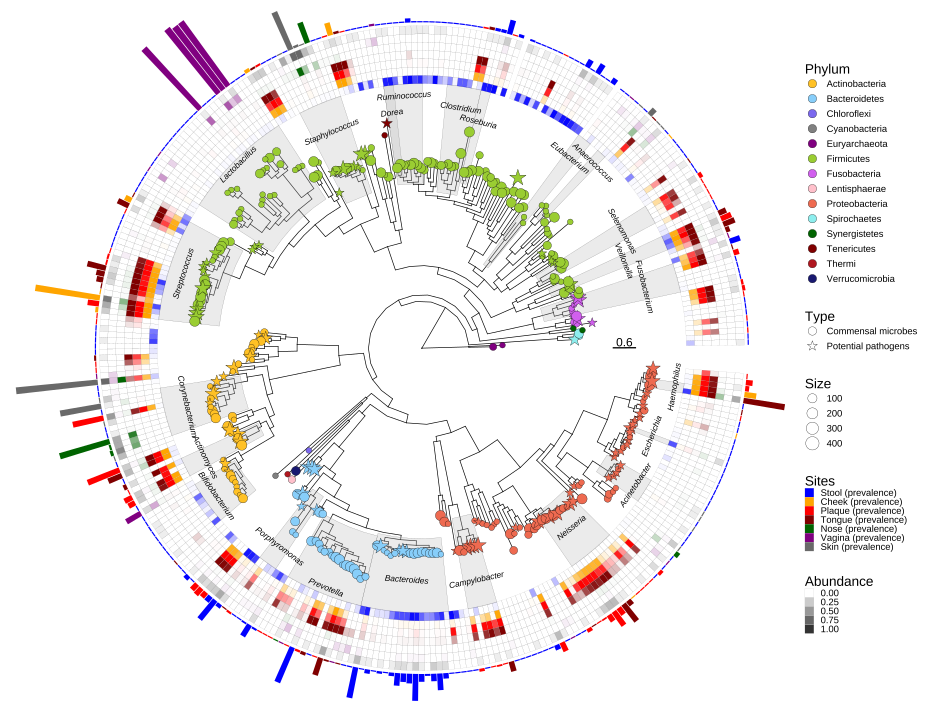

The geom_fruit() layer can be used to add extra visualization to your sunburst plot through the ggtreeExtra package

# 2.0.0 What are network diagrams and how can we use them?

We’ve seen a lot of trees today but a closely related structure is the network diagram. They share similar concepts in that both have nodes and branches. However, nodes are called **vertices** and can represent almost anything, branches between nodes are **edges** and can span across multiple nodes, instead of in a bifurcating tree relationship. Relationships between vertices can be bidirectional, and depending on what you’d like to present, multiple parallel edges may exist. We saw a specific version of network diagrams in Lecture 04 with our Sankey plots!

Network graphs are great for showing the interconnections between entities within your data. This kind of visualization can also help us realize where subtle connections occur (or don’t occur!). Depending on how you’ve weighted or chosen edges, you can convey how strong relationships between entities are as well.

To work with graph data and plot it, we’ll be using a couple of companion packages: `tidygraph` and `ggraph`. More about that later!

Since we already have some metadata about COVID genomes, let’s see if we can’t convert some of it to a network diagram to better understand strain information? We’ll begin by selecting some information from our Nextstrain metadata set.

```r
str(SC2_metadata.df, give.attr = FALSE)
```

```
## spc_tbl_ [6,627 x 24] (S3: spec_tbl_df/tbl_df/tbl/data.frame)
##  $ Strain                    : chr [1:6627] "Wuhan/WH01/2019" "USA/MA1/2020" "Canada/ON_ON-VIDO-01-2/2020" "Canada/ON_VIDO-01/2020" ...
##  $ GISAID clade              : chr [1:6627] "L" "L" "L" "L" ...
##  $ Nextstrain clade          : chr [1:6627] "19A" "19A" "19A" "19A" ...
##  $ Age                       : num [1:6627] 44 21 NA NA 54 NA 47 47 23 55 ...
##  $ Clade                     : chr [1:6627] "19A" "19A" "19A" "19A" ...
##  $ Country                   : chr [1:6627] "Asia" "USA" "Canada" "Canada" ...
##  $ Admin Division            : chr [1:6627] "Asia" "Massachusetts" "Ontario" "Ontario" ...
##  $ Admin Division of exposure: chr [1:6627] "Asia" "Asia" "Ontario" "Asia" ...
##  $ gisaid_epi_isl            : chr [1:6627] "EPI_ISL_406798" "EPI_ISL_409067" "EPI_ISL_425177" "EPI_ISL_413015" ...
##  $ Host                      : chr [1:6627] "Human" "Human" "Human" "Human" ...
##  $ Originating Lab           : chr [1:6627] "General Hospital of Central Theater Command of People's Liberation Army of China" "Massachusetts Department of Public Health" "Public Health Ontario" "Public Health Ontario Laboratory" ...
##  $ PANGO lineage             : chr [1:6627] "B" "B" "B" "B" ...
##  $ Submission Date           : chr [1:6627] "Older" "Older" "Older" "Older" ...
##  $ Region                    : chr [1:6627] "Asia" "North America" "North America" "North America" ...
##  $ Region of exposure        : chr [1:6627] "Asia" "Asia" "North America" "Asia" ...
##  $ Sex                       : chr [1:6627] "Male" "Male" "Male" "Male" ...
##  $ strain                    : chr [1:6627] "Wuhan/WH01/2019" "USA/MA1/2020" "Canada/ON_ON-VIDO-01-2/2020" "Canada/ON_VIDO-01/2020" ...
##  $ Emerging Nextstrain clade : chr [1:6627] "19A" "19A" "19A" "19A" ...
##  $ Submitting Lab            : chr [1:6627] "BGI & Institute of Microbiology, Chinese Academy of Sciences & Shandong First Medical University & Shandong Aca"| __truncated__ "Pathogen Discovery, Respiratory Viruses Branch, Division of Viral Diseases, Centers for Disease Control and Prevention" "Pu…
##  $ url                       : logi [1:6627] NA NA NA NA NA NA ...
##  $ Collection Data           : Date[1:6627], format: "2019-12-26" "2020-01-29" ...
##  $ Author                    : chr [1:6627] "Weijun Chen et al (https://dx.doi.org/10.1016/S0140-6736(20)30251-8)" "Clinton R. Paden et al (https://dx.doi.org/10.1101/2020.03.09.20032896)" "Amrit S. Boese et al" "Shari Tyson et al" ...
##  $ Country of exposure       : chr [1:6627] NA "Asia" NA "Asia" ...
##  $ Location                  : chr [1:6627] NA "Boston" NA NA ...
```

### 2.0.1 Perform a bit of data wrangling to select our data

Before we jump into making some network diagrams, we’ll want to trim down the data from `SC2_metadata.df`. We don’t need all of the data that is currently in this table. Instead we’ll trim it down to 10 variables:

- `Strain`: the strain name of the genome. This matches the tips of our original trees we made in section 1.0.0.
- `Country`: the country where the case was reported.
- `Admin Division`: the sub-region where the case was identified
- `Admin Division of exposure`: the sub-region believed to be the source of the strain.
- `Region`: appears to be the continent where the case was identified.
- `Region of exposure`: the continent was the case was contracted.
- `Nextstrain clade`: the Nextstrain clade for this strain
- `GISAID clade`: the clade classifiction defined by the Global Initiative on Sharing Avian Influenza Data
- `PANGO lineage`: the Phylogenetic Assignment of Named Global Outbreak lineage
- `Collection Data`: the collection date of the strain (also misspelled)

```r
SC2_graph_info.df <-

# Pass along our metadata
SC2_metadata.df %>%

  # We'll grab information about each case that relates to its geographical region
  select(Strain, Country, 'Admin Division', 'Admin Division of exposure', 'Region of exposure', Region,
         'Nextstrain clade', 'GISAID clade', 'PANGO lineage', 'Collection Data') %>%

  # Do a bunch of renaming for our variables
  rename(source_location = 'Admin Division of exposure',
         case_location = 'Admin Division',
         source_region = 'Region of exposure',
         case_region = 'Region',
         collection_date = 'Collection Data',
         Nextstrain = 'Nextstrain clade',
         GISAID = 'GISAID clade',
         PANGO = 'PANGO lineage'
        )

head(SC2_graph_info.df)
```

```
## # A tibble: 6 x 10
##   Strain         Country case_location source_location source_region case_region
##   <chr>          <chr>   <chr>         <chr>           <chr>         <chr>
## 1 Wuhan/WH01/20~ Asia    Asia          Asia            Asia          Asia
## 2 USA/MA1/2020   USA     Massachusetts Asia            Asia          North Amer~
## 3 Canada/ON_ON-~ Canada  Ontario       Ontario         North America North Amer~
## 4 Canada/ON_VID~ Canada  Ontario       Asia            Asia          North Amer~
## 5 USA/CA-CDC-5/~ USA     California    Asia            Asia          North Amer~
## 6 Taiwan/CGMH-C~ Asia    Asia          Asia            Asia          Asia
## # i 4 more variables: Nextstrain <chr>, GISAID <chr>, PANGO <chr>,
## #   collection_date <date>
```

## 2.1.0 Use the `tidygraph` package to help prepare data

Now that we have some information that we want to work with, we want to convert that kind of data to something that can be interpreted into a graph. The `tidygraph` package provides a way to hook graph data into the `tidyverse` so that we can use common verbs and ideas to filter and work with it. Using this package we can convert our dataframe information into a `tbl_graph` object which is actually an `igraph` object.

The function we’ll use to convert our data is `as_tbl_graph()` but it has some expectations about the data. The parameters of this function are:

- `x`: the data frame we’d like to convert to an `igraph`.
- `nodes`: a data frame with our node information.
- `edges`: a data frame of two columns containing integers matching node information to describe the relationship between nodes.

If you have both a nodes and edges data frame you can certainly generate a table this way. However, we have a complex dataframe and we want to track all of the information in it. To that end we will *add* columns `from` and `to` based on variables that already exist and the graph nodes will be generated from this information. When we provide the data frame, the function will recognize the columns present and produce node-based data and generate edge characteristics from our other columns.

```r
# Now we'll add some specific variables used to generate our graph table

SC2_graph_info.df %>%

  # Create our "from" and "to" columns in our data frame
  mutate(from = source_location,
         to = Country
        ) %>%

  # Filter for just strain data from Canada and Asia
  filter(Country %in% c("Canada", "Asia")) %>%

  # Convert to an igraph
  as_tbl_graph() %>%

  # Look at the structure of the igraph
  str()
```

[output not shown]

## 2.2.0 Plot your graph information with `ggraph()`

The `ggraph()` function is one of many from a package of the same name. This package adds geoms and architecture that is compatible with `ggplot2` (for the most part). Some of the functions we are interested in are:

| Component | Function | Description |
| --- | --- | --- |
| Graph | ggraph | The equivalent of the call to `ggplot`, it sets up the basic information about the graph plot |
| Edge | geom_edge_link | Produces edges between points |
| Edge | geom_edge_fan | Produces edges between points but accounts for parallel edges, creating arcs that fan out |
| Edge | geom_edge_parallel | Produces multiple edges between points with parallel lines representing parallel edges |
| Edge | geom_edge_loop | Used to represent edges that start and end at the same node. Does not account for parallel edges |
| Node | geom_node_point | Add basic nodes to your graph |
| Node | geom_node_circle | Add nodes to your graph that can be scaled by the coordinate system |

The `ggraph()` function takes in 3 parameters:

- `graph`: the `igraph` object that we’ll base the graph on.
- `layout`: the type of layout for the graph. There are many options including: auto, dendrogram, linear, matrix, treemap (yep!) circlepack, partition, and hive.
- `circular`: a logical stating whether the layout should be transformed into a radial representation. It can’t be applied to all layouts (think `polar_coord`).

```r
# Now we'll add some specific variables used to generate our graph table

SC2_graph_info.df %>%

  # Generate our from and to edge information
  mutate(from = source_region,
        to = case_region
        ) %>%

  # Convert to an igraph and pass it on to be plotted
  as_tbl_graph() %>%

  # 1. Data
  ggraph(.) +
      # 2. Aesthetics
      theme(text = element_text(size = 10)) +

      ### 2.2.0 Add our edges
      geom_edge_link(aes(colour = Nextstrain), arrow=arrow(), width = 1) +

      ### 2.2.0 Add our nodes and label them
      geom_node_point(size = 7) +
      geom_node_text(aes(label = name), size = 5, repel = TRUE)
```

[output not shown]

### 2.2.1 Use `geom_edge_fan()` to visualize parallel edges

Let’s try it out.

```r
# Now we'll add some specific variables used to generate our graph table

SC2_graph_info.df %>%

  # Generate our from and to edge information
  mutate(from = source_region,
        to = case_region
        ) %>%

  # Convert to an igraph
  as_tbl_graph() %>%

  # 1. Data

  ggraph(.) +
      # 2. Aesthetics
      theme(text = element_text(size = 10)) +

      ### 2.2.1 Add our edges
      geom_edge_fan(aes(colour = Nextstrain), arrow=arrow()) +

      # Add our nodes and label them
      geom_node_point(size = 7) +
      geom_node_text(aes(label = name), size = 5, repel = TRUE)
```

[output not shown]

### 2.2.2 Filter and choose your data carefully to better visualize it

The metadata we’ve chosen isn’t very detailed and that can be the case for many datasets so you’ll want to be sure of how you pick your nodes. Right now we are picking our `from` and `to` values based on the supposed source and identifying continents of the strain.

While other variables could offer more information, they can vary in consistency from a region (Asia) to a province (Ontario) as seen in variable `case_location`. Definitely aim to be consistent when you’re working with your data otherwise the nodes may have less meaning.

Let’s try looking at `source_region` (Continent) to `case_location` (Divisions) as it relates to data from Canada and Asia

```r
# Now we'll add some specific variables used to generate our graph table

SC2_graph_info.df %>%

  # Generate our from and to edge information
  mutate(from = source_region,
        to = case_location
        ) %>%

  # Filter for Canada data
  filter(Country %in% c("Canada", "Asia")) %>%

  # Convert to an igraph
  as_tbl_graph() %>%

  # 1. Data
  ggraph(.) +
    # 2. Aesthetics
    theme(text = element_text(size = 20)) +

    # Add our edges
    geom_edge_fan(aes(colour = Nextstrain), arrow=arrow()) +
    ### 2.2.2 If we suspect looping edges, we need to define that layer specifically
    geom_edge_loop() +

    # Add our nodes and label them
    geom_node_point(size = 7) +
    geom_node_text(aes(label = name), size = 7, repel = TRUE)
```

[output not shown]

## 2.3.0 There are many more visualizations from `ggraph`

We’ve really only covered linear graph layouts in our data but there are actually many *kinds* of graphs that this package can produce. The `layout` parameter is the key to exploring all of the graph types available. Of course your data layout all has to make sense! You’ll find great examples from [data-imaginist.com](https://www.data-imaginist.com/2017/ggraph-introduction-layouts/) like this circlepack graph:

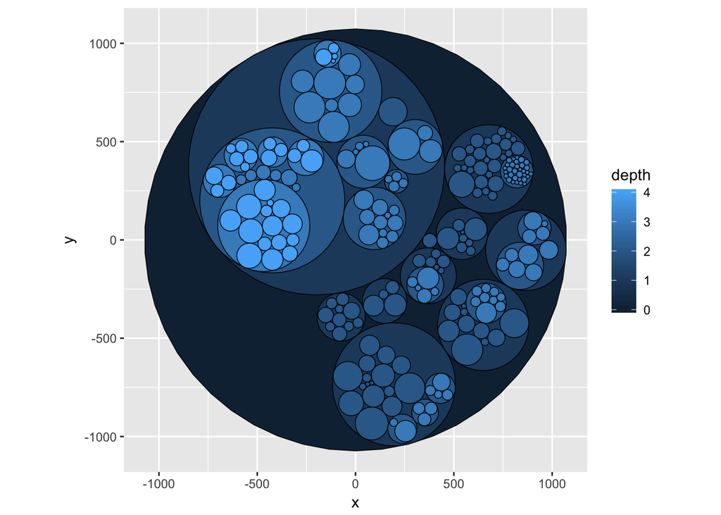

There are all kinds of network graphs that can use additional layers of metadata to shape and present your data

# 3.0.0 Sequence motifs and genomic markers

When working with data sometimes you may be working with sequence-specific data for analysis of motifs or you may have a large set of data describing genomic markers like single nucleotide variants. Two popular visualizations in this domain are the sequence logo and Manhattan plot.

## 3.1.0 Generate sequence logos with `ggseqlogo`

This one is short and simple. If you have a series of sequences you’d like to plot based on frequency of each bases you see at each position, the sequence logo is for you. The `ggseqlogo` package offers a simple `ggplot2`-compatible set of geoms you can add to your graph in order to represent this data.

Your data can come in two flavours:

1. A named list where each index position is a vector of sequences, and the names of each index can have meaning (like a transcription factor).
2. A frequency matrix where columns correspond to positions, and rownames correspond to bases (or amino acids). Each entry is the number of times that a base is seen at a specific position. These matrices could be daisy-chained in a list.

Let’s work with the former since it does have some flexibility and looks like something we recognize.

```r
# Build an example sequence set (it's actually from the SARS-CoV-2 spike sequence )
example_seq1 <- c("aacccactaatggtgttggtt","aatccactaatggtgttgctt","aacccaataatagtgttggtt",
                 "aacccactaatggtgttggtt","aacccactaatggtattgatt","accccactaatgttgttggtt",
                 "aacccactaatggtgttggtt","aacccactaatggtattgatt","accccactaatgttgttggtt") %>%

  # Convert it all to upper case because ggseqlogo appears to hate when we don't
  str_to_upper()

example_seq2 <- c("cacccactaatggtgttggtg","aatccactaatggtgttgctt","aacccaataatagtgttggtt",
                 "cacccactaatggtgttggtg","aacccactaatggtattgatt","accccactaatgttgttggtt",
                 "cacccactaatggtgttggtg","aacccactaatggtattgatt","accccactaatgttgttggtt") %>%

  # Convert it all to upper case because ggseqlogo appears to hate when we don't
  str_to_upper()

# Build our list
example_seq.list = list(spike_set1 = example_seq1, spike_set2 = example_seq2)

# Take a look at our list
str(example_seq.list)
```

```
## List of 2
##  $ spike_set1: chr [1:9] "AACCCACTAATGGTGTTGGTT" "AATCCACTAATGGTGTTGCTT" "AACCCAATAATAGTGTTGGTT" "AACCCACTAATGGTGTTGGTT" ...
##  $ spike_set2: chr [1:9] "CACCCACTAATGGTGTTGGTG" "AATCCACTAATGGTGTTGCTT" "AACCCAATAATAGTGTTGGTT" "CACCCACTAATGGTGTTGGTG" ...
```

### 3.1.1 Plot your logo information with the `ggseqlogo()` wrapper function

We have two options to look at our sequence data. The `ggseqlogo()` is a wrapper that sets up the entire plot for us including if you’d like to facet the data. If you just want a single logo then you pass parts of the list individually.

If you’d like multiple logos, you can decided their layout with the `ncol` or `nrow` parameters. The other parameters are:

- `facet` which will accept either “wrap” or “grid”.
- `scales` which will accept the scale types for the facet geom.

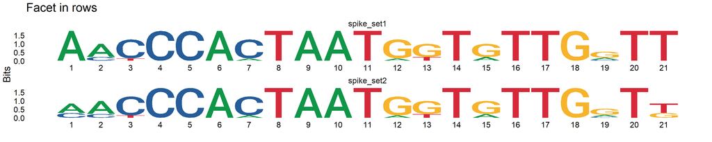

```r
# Make a 2-row sequence logo
ggseqlogo(example_seq.list, nrow=2) +
  theme(text = element_text(size = 20)) +
  labs(title = "Facet in rows")
```

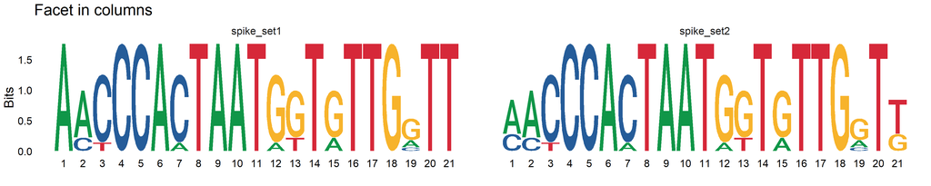

```r
# Make a 2-column sequence logo
ggseqlogo(example_seq.list, ncol=2) +
  theme(text = element_text(size = 20)) +
  labs(title = "Facet in columns")
```

### 3.1.2 Plot your logo information with `geom_logo()`

To plot our data we can use `ggplot` language that we are familiar with and add a layer to our plot with the `geom_logo()` function. This layer is also supplied by the `ggseqlogo` package. In order for this to function properly, however, we need to define our parameters as:

- `data`: the vector with of our sequence data
- `seq_type`: sets the type of sequence like “DNA”, “RNA” or “AA”
- `method`: the y-scale of our logo either in “bits” (information value) or by “probability”

These and other parameters can also be set in the `ggseqlogo()` function too.

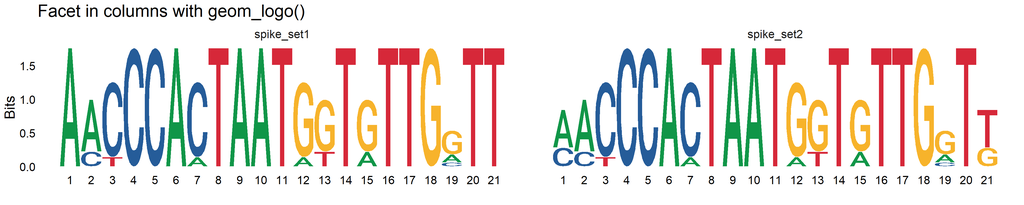

```r
# 1. Data
ggplot() +
  # 2. Aesthetics
  theme_logo() +
  theme(text = element_text(size = 20)) +
  labs(title = "Facet in columns with geom_logo()") +

  # 4. Geoms
  geom_logo(data = example_seq.list, seq_type="DNA", method = "bits") +

  # 6. Facet
  facet_wrap(~seq_group, ncol=2)
```

## 3.2.0 The Manhattan plot for all your genome-position visualization needs

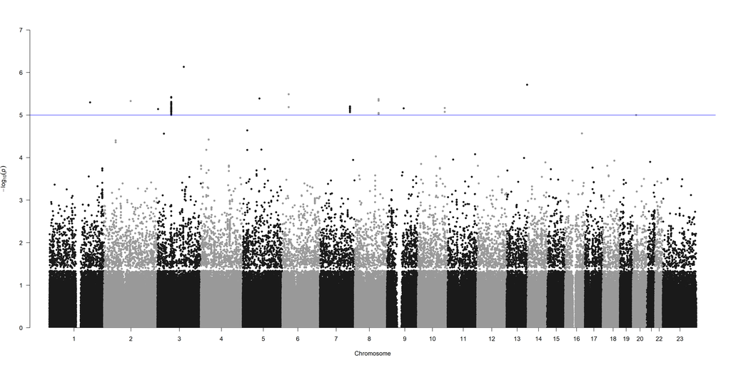

The Manhattan plot is usually used in visualizing data across the genome from LOD scores to marker proportions.

Named for it’s visual similarity to the Manhattan skyline of singular towering skyscrapers scattered above low-level buildings, this plot is commonly used for visualizing genomic markers across an ordered linear axis like a series of chromosomes. The y-axis of the values can represent LOD scores or proportions of marker representation. This is frequently used to visualize GWAS or mapping data.

This is another scatterplot that we can generate directly in `ggplot` with some effort/setup or we can use a package like `qqman`.

First let’s look at the kind of data. Fun fact! You can read in archived/zipped data as well, although be careful, GWAS files can be quite large!

```r
load("data/Lecture06.RData")

str(GWAS_data.df, give.attr = FALSE)
```

```
## spc_tbl_ [527,210 x 12] (S3: spec_tbl_df/tbl_df/tbl/data.frame)
##  $ CHR           : num [1:527210] 23 23 23 23 23 23 23 23 23 23 ...
##  $ POS           : num [1:527210] 2704803 2711723 2723550 2788926 2800788 ...
##  $ rsid          : chr [1:527210] "rs774167872" "rs311171" "rs7889852" "rs750465443" ...
##  $ SNPID         : chr [1:527210] "X:2704803_T_C" "X:2711723_G_A" "X:2723550_C_T" "X:2788926_A_C" ...
##  $ Allele1       : chr [1:527210] "T" "G" "C" "A" ...
##  $ Allele2       : chr [1:527210] "C" "A" "T" "C" ...
##  $ AF_Allele2    : num [1:527210] 0.0129 0.0116 0.0115 0.0148 0.0147 ...
##  $ imputationInfo: num [1:527210] 1 0.589 0.858 0.395 0.784 ...
##  $ N             : num [1:527210] 135 135 135 135 135 135 135 135 135 135 ...
##  $ BETA          : num [1:527210] -0.235 -1.163 -0.993 -0.902 -1.745 ...
##  $ SE            : num [1:527210] 1.218 1.554 1.48 0.993 2.225 ...
##  $ p.value       : num [1:527210] 0.847 0.454 0.502 0.363 0.433 ...
```

### 3.2.1 Use the `manhattan()` function to generate a plot

To generate our Manhattan plot we can use the `manhattan()` wrapper function which will require four sets of parameter information:

- `chr`: the column name with the chromosome information for a given SNP.
- `bp`: the basepair position of the SNP.
- `snp`: the ID of the SNP usually a RefSNP ID (RSID) of some kind.
- `p`: the p-value for that particular SNP generated from the case vs. control analysis. This will be converted to a $-log10(p)$ value for the y-axis.

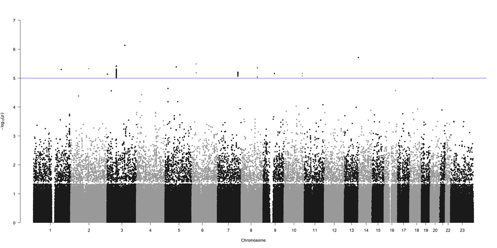

```r
# manhattan(gwasResults, chr="CHR", bp="BP", snp="SNP", p="P")

GWAS_data.df %>%
# You can filter your data if you want this step to run faster
# filter(CHR %in% c(1:5)) %>%

  manhattan(., chr="CHR", bp="POS", snp="rsid", p="p.value")
```

### 3.2.2 Use the `highlight` parameter to identify markers of interest

Either way, you can highlight SNP results based on a provided list. In this case, we can generate a list ourselves by filtering on the `p.value` variable.

```r
snp_candidates <-

  # Pass along our GWAS data
  GWAS_data.df %>%

  # Filter it for low p-values
  filter(-log10(p.value) >= 5) %>%

  # Select SNP candidates
  pull(rsid) %>%
  unique()

# snp_candidates

# Plot our Manhattan plot
manhattan(GWAS_data.df,
          chr="CHR",
          bp="POS",
          snp="rsid",
          p="p.value",
          highlight = snp_candidates)
```

[figure not shown]

# 4.0.0 Tips and Tricks

When preparing figures for a presentation or manuscript consider some of the following tips/tricks that I’ve accumulated over the years. Not all may apply to your work but these can certainly be helpful.

## 4.1.0 How many figures do you need to tell your story?

Regardless of whether or not you’ll be giving a talk or submitting a manuscript you’ll want to consider how many figures you need to tell your story.

- **Most major publications** will have 4-6 main figures with usually an (unlimited nowadays) number of supplemental figures.
  - Main figures can usually accomodate up to 4-8 subpanels depending on the complexity of your data/subject
- **Presentations** generally have 1 slide per minute of talk so plan accordingly.
  - A complicated figure or figure type should be given some extra time to initially explain but if you are using the format often, later versions will be simpler to digest. Spend time discussing the first occurrence of a figure type to build a solid foundation!

## 4.2.0 Manuscript specifics

While publication requirements vary from journal to journal, most have similar rules

- Minimum dpi (resolution) of your images: 300dpi
- Minimum font size (ie the very smallest any font should be on a sub panel): Usually 6-7pts
- Maximum image size. There is usually a maximum figure size in terms of dimensions but this really can vary widely. Check with a few potential publications first to get an idea of the main size/layout (portrait vs landscape) for figures.
- Keep ALL figure data organized for submission! This is the standard now and can include sequences, or any data that was used to create your figures. You can organize this in a single CSV, or worksheet-based file.
- Figures should be decipherable at a glance. A successful figure’s general message can be understood without having to read through the figure legends. This is not *always* possible but is certainly something to strive for.
  - Figure titles are optional. Often helpful for the above point but you sacrifice space to have them!

## 4.3.0 Presentation figures

- Make your font big enough to read. Unlike a manuscript, people cannot zoom in on your presentation figures
- Limit panels to 2-4 at most per figure.
- Forget about the title on your figure. Title the *slide* instead with your take-home message about the figure. Having an effective slide title tells your audience where to focus on your figure. This is *especially key* when you are presenting a complicated or “busy” figure.
- When presenting a figure with multiple categories or ideas, reveal it piecemeal. Present the base idea (ie a control) and then reveal the next part of the panel showing your first experimental condition, then your second etc. This allows the audience to acclimate to the idea you wish to convey.
- If you can’t read the text of a figure because there are just too many things, consider simplifying or removing the text. This will reduce on distracting imagery and focus your message to your audience.

## 4.4.0 Things to think about when coding

- Keep a script (or notebook!) for remaking all your figures!
  - Simplify with a few variables things like the location of your datasets!
  - Build functions to make figures of the same type with different datasets.
  - Create a master file/table to import and use these datasets and functions.
- Create a specific colour-scheme for your figures
  - Try to use the same colour for controls versus specific mutant genotypes you may be examining or re-using frequently
  - Use a colourblind-friendly palette
- Save your plots as SVG, PNG or TIFFs
  - SVGs are vectorized meaning they are files representing lines, curves, and shapes based on a coordinate system. This means they are generally resolutionless and can be blown up to any size as needed. Great for working with on presentations and simple to alter in most image editing programs. Ideal for using on graphs and ggplot figures but not microscopy or other digital images.
  - Avoid JPEGs as much as possible. The tend to have poor (lossy) encoding that can create resolution loss unless you save them as big high-quality JPEG versions (lossless).

# 5.0.0 Class Summary

With this final lecture we’ve covered the spectrum of visualizations covering the most basic of scatter- and barplots, graduating to boxplots, violin plots, and their variants. We’ve covered high-throughput data visualizations including volcano plots, heatmaps, and principal component analysis. Furthermore we looked at how simple the projection of high-dimension data can be with t-SNE and UMAP.

We finished our course today covering phylogenetic trees, network graphs, and some sequence analysis visualizations. Overall you now have the tools to wrangle data that may appear in all sorts of formats along with a better understanding of when and how to prepare some of the most common data visualizations in your burgeoning science careers.

Congratulations and good luck on your data science journey!

### 5.0.1 Post-course survey

We have created a post-course survey you can fill out anonymously. You can use this survey as an opportunity to tell us about your experience and help shape the future offerings of this series. Please take 5-10 minutes to fill out the survey. We really appreciate your feedback!

[Anonymous Google Survey found here](https://forms.gle/11b1c6yAe3U9tJNo7)

## 5.1.0 Weekly assignment

This week’s assignment will be found under the current lecture folder under the “assignment” subfolder. It will include an R markdown notebook that you will use to produce the code and answers for this week’s assignment. Please provide answers in markdown or code cells that immediately follow each question section.

|  | Assignment breakdown |  |
| --- | --- | --- |
| Code | 50% | - Does it follow best practices? |
|  |  | - Does it make good use of available packages? |
|  |  | - Was data prepared properly |
| Answers and Output | 50% | - Is output based on the correct dataset? |
|  |  | - Are groupings appropriate |
|  |  | - Are correct titles/axes/legends correct? |
|  |  | - Is interpretation of the graphs correct? |

Since coding styles and solutions can differ, students are encouraged to use best practices. Assignments *may* be rewarded for well-coded or elegant solutions.

You can save and download the markdown notebook in its native format. Submit this file to the the appropriate assignment section by 12:59 pm on the date of our next class: April 24th, 2025.

## 5.2.0 Acknowledgements

**Revision 1.0.0**: created and prepared for **CSB1021H S LEC0141**, 03-2021 by Calvin Mok, Ph.D. *Bioinformatician, Education and Outreach, CAGEF.*

**Revision 1.0.1**: edited and prepared for **CSB1020H S LEC0141**, 03-2022 by Calvin Mok, Ph.D. *Bioinformatician, Education and Outreach, CAGEF.*

**Revision 1.0.2**: edited and prepared for **CSB1020H S LEC0141**, 03-2023 by Calvin Mok, Ph.D. *Bioinformatician, Education and Outreach, CAGEF.*

**Revision 2.0.0**: Revised and prepared for **CSB1020H S LEC0141**, 03-2024 by Calvin Mok, Ph.D. *Bioinformatician, Education and Outreach, CAGEF.*

**Revision 2.0.1**: Revised and prepared for **CSB1020H S LEC0141**, 03-2025 by Calvin Mok, Ph.D. *Bioinformatician, Education and Outreach, CAGEF.*

## 5.3.0 References

The book of `ggtree` from the Yu Lab: https://yulab-smu.top/treedata-book/index.html

Chapter 10 of `ggtree` with amazing and complicated plots: https://yulab-smu.top/treedata-book/chapter10.html

More information on the `ggraph` package: https://cran.r-project.org/web/packages/ggraph/ggraph.pdf

`ggseqlogo` package information: https://cran.r-project.org/web/packages/ggseqlogo/ggseqlogo.pdf

Manhattan plot tutorial: https://www.r-graph-gallery.com/101_Manhattan_plot.html

GWAS p-value threshold: https://www.nature.com/articles/s41380-020-0670-3?proof=t

More on GWAS thresholds for significance: https://www.nature.com/articles/ejhg2015269.pdf

## The Center for the Analysis of Genome Evolution and Function (CAGEF)

The Centre for the Analysis of Genome Evolution and Function (CAGEF) at the University of Toronto offers comprehensive experimental design, research, and analysis services in microbiome and metagenomic studies, genomics, proteomics, and bioinformatics.

From targeted DNA amplicon sequencing to transcriptomes, whole genomes, and metagenomes, from protein identification to post-translational modification, CAGEF has the tools and knowledge to support your research. Our state-of-the-art facility and experienced research staff provide a broad range of services, including both standard analyses and techniques developed by our team. In particular, we have special expertise in microbial, plant, and environmental systems.

For more information about us and the services we offer, please visit https://www.cagef.utoronto.ca/.

[figure not shown]